# Project2_Classification_Pavithra_Bharat

Project Description:

- Use same datasets as Project 1.
- Preprocess data: Explore data and apply data scaling.

Regression Task:

- Apply any two models with bagging and any two models with pasting.
- Apply any two models with adaboost boosting
- Apply one model with gradient boosting
- Apply PCA on data and then apply all the models in project 1 again on data you get from PCA. Compare your results with results in project 2. You don't need to apply all the models twice. Just copy the result table from project 1, prepare similar table for all the models after PCA and compare both tables. Does PCA help in getting better results?
- Apply deep learning models covered in class

Classification Task:

- Apply two voting classifiers - one with hard voting and one with soft voting
- Apply any two models with bagging and any two models with pasting.
- Apply any two models with adaboost boosting
- Apply one model with gradient boosting
- Apply PCA on data and then apply all the models in project 1 again on data you get from PCA. Compare your results with results in project 1. You don't need to apply all the models twice. Just copy the result table from project 1, prepare similar table for all the models after PCA and compare both tables. Does PCA help in getting better results?
- Apply deep learning models covered in class

Deliverables:

- Use markdown to provide inline comments for this project.
- Your outputs should be clearly executed in the notebook i.e. we should not need to rerun the code to obtain the outputs.
- Visualization encouraged.
- If you are submitting two different files, then please only one group member submit both the files. If you submit two files separately from different accounts, it will be submitted as two different attempts.
- If you are submitting two different files, then please follow below naming convetion: Project2_Regression_GroupXX_Firstname1_Firstname2.ipynb Project2_Classification_GroupXX_Firstname1_Firstname2.ipynb
- If you are submitting single file, then please follow below naming convetion: Project2_Both_GroupXX_Firstname1_Firstname2.ipynb

Questions regarding the project:

- We have created a discussion board under Projects folder on e-learning. Create threads over there and post your queries related to project there.
- We will also answer queries there. We will not be answering any project related queries through the mail.

## libraries

```python
import numpy as np
import pandas as pd
import matplotlib.pyplot as plt
%matplotlib inline
import seaborn as sns
import warnings
warnings.filterwarnings("ignore")
from sklearn import metrics
from sklearn.metrics import classification_report, confusion_matrix
from sklearn.metrics import accuracy_score, precision_score, recall_score, f1_score, roc_auc_score, cohen_kappa_score
```

## Using pandas reading the audit_risk and trial.csv.

```python
audit_risk_df = pd.read_csv("audit_risk.csv")
trial_df = pd.read_csv("trial.csv")
audit_risk_df.T
```

|  | 0 | 1 | 2 | 3 | 4 | 5 | 6 | 7 | 8 | 9 | ... | 766 | 767 | 768 | 769 | 770 | 771 | 772 | 773 | 774 | 775 |
| --- | --- | --- | --- | --- | --- | --- | --- | --- | --- | --- | --- | --- | --- | --- | --- | --- | --- | --- | --- | --- | --- |
| Sector_score | 3.89 | 3.89 | 3.89 | 3.89 | 3.89 | 3.89 | 3.89 | 3.89 | 3.89 | 3.89 | ... | 55.57 | 55.57 | 55.57 | 55.57 | 55.57 | 55.57 | 55.57 | 55.57 | 55.57 | 55.57 |
| LOCATION_ID | 23 | 6 | 6 | 6 | 6 | 6 | 7 | 8 | 8 | 8 | ... | 8 | 18 | 9 | 16 | 18 | 9 | 16 | 14 | 18 | 15 |
| PARA_A | 4.18 | 0 | 0.51 | 0 | 0 | 0 | 1.1 | 8.5 | 8.4 | 3.98 | ... | 0.8 | 0.36 | 0.44 | 0.51 | 0.75 | 0.49 | 0.47 | 0.24 | 0.2 | 0 |
| Score_A | 0.6 | 0.2 | 0.2 | 0.2 | 0.2 | 0.2 | 0.4 | 0.6 | 0.6 | 0.6 | ... | 0.2 | 0.2 | 0.2 | 0.2 | 0.2 | 0.2 | 0.2 | 0.2 | 0.2 | 0.2 |
| Risk_A | 2.508 | 0 | 0.102 | 0 | 0 | 0 | 0.44 | 5.1 | 5.04 | 2.388 | ... | 0.16 | 0.072 | 0.088 | 0.102 | 0.15 | 0.098 | 0.094 | 0.048 | 0.04 | 0 |
| PARA_B | 2.5 | 4.83 | 0.23 | 10.8 | 0.08 | 0.83 | 7.41 | 12.03 | 11.05 | 0.99 | ... | 0.57 | 0.54 | 0.53 | 0.5 | 0.45 | 0.4 | 0.37 | 0.04 | 0 | 0 |
| Score_B | 0.2 | 0.2 | 0.2 | 0.6 | 0.2 | 0.2 | 0.4 | 0.6 | 0.6 | 0.2 | ... | 0.2 | 0.2 | 0.2 | 0.2 | 0.2 | 0.2 | 0.2 | 0.2 | 0.2 | 0.2 |
| Risk_B | 0.5 | 0.966 | 0.046 | 6.48 | 0.016 | 0.166 | 2.964 | 7.218 | 6.63 | 0.198 | ... | 0.114 | 0.108 | 0.106 | 0.1 | 0.09 | 0.08 | 0.074 | 0.008 | 0 | 0 |
| TOTAL | 6.68 | 4.83 | 0.74 | 10.8 | 0.08 | 0.83 | 8.51 | 20.53 | 19.45 | 4.97 | ... | 1.37 | 0.9 | 0.97 | 1.01 | 1.2 | 0.89 | 0.84 | 0.28 | 0.2 | 0 |
| numbers | 5 | 5 | 5 | 6 | 5 | 5 | 5 | 5.5 | 5.5 | 5 | ... | 5 | 5 | 5 | 5 | 5 | 5 | 5 | 5 | 5 | 5 |
| Score_B.1 | 0.2 | 0.2 | 0.2 | 0.6 | 0.2 | 0.2 | 0.2 | 0.4 | 0.4 | 0.2 | ... | 0.2 | 0.2 | 0.2 | 0.2 | 0.2 | 0.2 | 0.2 | 0.2 | 0.2 | 0.2 |
| Risk_C | 1 | 1 | 1 | 3.6 | 1 | 1 | 1 | 2.2 | 2.2 | 1 | ... | 1 | 1 | 1 | 1 | 1 | 1 | 1 | 1 | 1 | 1 |
| Money_Value | 3.38 | 0.94 | 0 | 11.75 | 0 | 2.95 | 44.95 | 7.79 | 7.34 | 1.93 | ... | 0 | 0.21 | 0 | 0.09 | 0 | 0 | 0 | 0 | 0 | 0.32 |
| Score_MV | 0.2 | 0.2 | 0.2 | 0.6 | 0.2 | 0.2 | 0.6 | 0.4 | 0.4 | 0.2 | ... | 0.2 | 0.2 | 0.2 | 0.2 | 0.2 | 0.2 | 0.2 | 0.2 | 0.2 | 0.2 |
| Risk_D | 0.676 | 0.188 | 0 | 7.05 | 0 | 0.59 | 26.97 | 3.116 | 2.936 | 0.386 | ... | 0 | 0.042 | 0 | 0.018 | 0 | 0 | 0 | 0 | 0 | 0.064 |
| District_Loss | 2 | 2 | 2 | 2 | 2 | 2 | 2 | 2 | 2 | 2 | ... | 2 | 2 | 2 | 2 | 2 | 2 | 2 | 2 | 2 | 2 |
| PROB | 0.2 | 0.2 | 0.2 | 0.2 | 0.2 | 0.2 | 0.2 | 0.2 | 0.2 | 0.2 | ... | 0.2 | 0.2 | 0.2 | 0.2 | 0.2 | 0.2 | 0.2 | 0.2 | 0.2 | 0.2 |
| RiSk_E | 0.4 | 0.4 | 0.4 | 0.4 | 0.4 | 0.4 | 0.4 | 0.4 | 0.4 | 0.4 | ... | 0.4 | 0.4 | 0.4 | 0.4 | 0.4 | 0.4 | 0.4 | 0.4 | 0.4 | 0.4 |
| History | 0 | 0 | 0 | 0 | 0 | 0 | 0 | 0 | 0 | 0 | ... | 0 | 0 | 0 | 0 | 0 | 0 | 0 | 0 | 0 | 0 |
| Prob | 0.2 | 0.2 | 0.2 | 0.2 | 0.2 | 0.2 | 0.2 | 0.2 | 0.2 | 0.2 | ... | 0.2 | 0.2 | 0.2 | 0.2 | 0.2 | 0.2 | 0.2 | 0.2 | 0.2 | 0.2 |
| Risk_F | 0 | 0 | 0 | 0 | 0 | 0 | 0 | 0 | 0 | 0 | ... | 0 | 0 | 0 | 0 | 0 | 0 | 0 | 0 | 0 | 0 |
| Score | 2.4 | 2 | 2 | 4.4 | 2 | 2 | 3.2 | 4.2 | 4.2 | 2.4 | ... | 2 | 2 | 2 | 2 | 2 | 2 | 2 | 2 | 2 | 2 |
| Inherent_Risk | 8.574 | 2.554 | 1.548 | 17.53 | 1.416 | 2.156 | 31.774 | 18.034 | 17.206 | 4.372 | ... | 1.674 | 1.622 | 1.594 | 1.62 | 1.64 | 1.578 | 1.568 | 1.456 | 1.44 | 1.464 |
| CONTROL_RISK | 0.4 | 0.4 | 0.4 | 0.4 | 0.4 | 0.4 | 0.4 | 0.4 | 0.4 | 0.4 | ... | 0.4 | 0.4 | 0.4 | 0.4 | 0.4 | 0.4 | 0.4 | 0.4 | 0.4 | 0.4 |
| Detection_Risk | 0.5 | 0.5 | 0.5 | 0.5 | 0.5 | 0.5 | 0.5 | 0.5 | 0.5 | 0.5 | ... | 0.5 | 0.5 | 0.5 | 0.5 | 0.5 | 0.5 | 0.5 | 0.5 | 0.5 | 0.5 |
| Audit_Risk | 1.7148 | 0.5108 | 0.3096 | 3.506 | 0.2832 | 0.4312 | 6.3548 | 3.6068 | 3.4412 | 0.8744 | ... | 0.3348 | 0.3244 | 0.3188 | 0.324 | 0.328 | 0.3156 | 0.3136 | 0.2912 | 0.288 | 0.2928 |
| Risk | 1 | 0 | 0 | 1 | 0 | 0 | 1 | 1 | 1 | 0 | ... | 0 | 0 | 0 | 0 | 0 | 0 | 0 | 0 | 0 | 0 |

27 rows × 776 columns

```python
audit_risk_df.rename(columns={'PROB': 'PROB1'}, inplace=True)
```

```python
print(audit_risk_df.columns)
print(trial_df.columns)
```

```
Index(['Sector_score', 'LOCATION_ID', 'PARA_A', 'Score_A', 'Risk_A', 'PARA_B',
       'Score_B', 'Risk_B', 'TOTAL', 'numbers', 'Score_B.1', 'Risk_C',
       'Money_Value', 'Score_MV', 'Risk_D', 'District_Loss', 'PROB1', 'RiSk_E',
       'History', 'Prob', 'Risk_F', 'Score', 'Inherent_Risk', 'CONTROL_RISK',
       'Detection_Risk', 'Audit_Risk', 'Risk'],
      dtype='object')
Index(['Sector_score', 'LOCATION_ID', 'PARA_A', 'SCORE_A', 'PARA_B', 'SCORE_B',
       'TOTAL', 'numbers', 'Marks', 'Money_Value', 'MONEY_Marks', 'District',
       'Loss', 'LOSS_SCORE', 'History', 'History_score', 'Score', 'Risk'],
      dtype='object')
```

# After reading the two datasets the following observations were made :

## Detection_Risk is a constant value

```python
audit_risk_df = audit_risk_df.drop("Detection_Risk", axis = 1)
```

```python
trial_df
```

|  | Sector_score | LOCATION_ID | PARA_A | SCORE_A | PARA_B | SCORE_B | TOTAL | numbers | Marks | Money_Value | MONEY_Marks | District | Loss | LOSS_SCORE | History | History_score | Score | Risk |
| --- | --- | --- | --- | --- | --- | --- | --- | --- | --- | --- | --- | --- | --- | --- | --- | --- | --- | --- |
| 0 | 3.89 | 23 | 4.18 | 6 | 2.5000 | 2 | 6.6800 | 5.0 | 2 | 3.380 | 2 | 2 | 0 | 2 | 0 | 2 | 2.4 | 1 |
| 1 | 3.89 | 6 | 0.00 | 2 | 4.8300 | 2 | 4.8300 | 5.0 | 2 | 0.940 | 2 | 2 | 0 | 2 | 0 | 2 | 2.0 | 0 |
| 2 | 3.89 | 6 | 0.51 | 2 | 0.2300 | 2 | 0.7400 | 5.0 | 2 | 0.000 | 2 | 2 | 0 | 2 | 0 | 2 | 2.0 | 0 |
| 3 | 3.89 | 6 | 0.00 | 2 | 10.8000 | 6 | 10.8000 | 6.0 | 6 | 11.750 | 6 | 2 | 0 | 2 | 0 | 2 | 4.4 | 1 |
| 4 | 3.89 | 6 | 0.00 | 2 | 0.0800 | 2 | 0.0800 | 5.0 | 2 | 0.000 | 2 | 2 | 0 | 2 | 0 | 2 | 2.0 | 0 |
| 5 | 3.89 | 6 | 0.00 | 2 | 0.8300 | 2 | 0.8300 | 5.0 | 2 | 2.950 | 2 | 2 | 0 | 2 | 0 | 2 | 2.0 | 0 |
| 6 | 3.89 | 7 | 1.10 | 4 | 7.4100 | 4 | 8.5100 | 5.0 | 2 | 44.950 | 6 | 2 | 0 | 2 | 0 | 2 | 3.2 | 1 |
| 7 | 3.89 | 8 | 8.50 | 6 | 12.0300 | 6 | 20.5300 | 5.5 | 4 | 7.790 | 4 | 2 | 0 | 2 | 0 | 2 | 4.2 | 1 |
| 8 | 3.89 | 8 | 8.40 | 6 | 11.0500 | 6 | 19.4500 | 5.5 | 4 | 7.340 | 4 | 2 | 0 | 2 | 0 | 2 | 4.2 | 1 |
| 9 | 3.89 | 8 | 3.98 | 6 | 0.9900 | 2 | 4.9700 | 5.0 | 2 | 1.930 | 2 | 2 | 0 | 2 | 0 | 2 | 2.4 | 1 |
| 10 | 3.89 | 8 | 5.43 | 6 | 10.7700 | 6 | 16.2000 | 5.0 | 2 | 4.420 | 2 | 2 | 0 | 2 | 0 | 2 | 3.6 | 1 |
| 11 | 3.89 | 8 | 15.38 | 6 | 40.1400 | 6 | 55.5200 | 5.0 | 2 | 0.960 | 2 | 2 | 1 | 4 | 1 | 4 | 4.0 | 1 |
| 12 | 3.89 | 8 | 5.47 | 6 | 7.6300 | 4 | 13.1000 | 5.0 | 2 | 10.430 | 6 | 2 | 0 | 2 | 1 | 4 | 3.6 | 1 |
| 13 | 3.89 | 8 | 1.09 | 4 | 0.3500 | 2 | 1.4400 | 5.0 | 2 | 0.000 | 2 | 2 | 0 | 2 | 0 | 2 | 2.2 | 1 |
| 14 | 3.89 | 8 | 0.00 | 2 | 0.8400 | 2 | 0.8400 | 5.0 | 2 | 0.007 | 2 | 2 | 0 | 2 | 0 | 2 | 2.0 | 0 |
| 15 | 3.89 | 13 | 1.95 | 4 | 9.0100 | 4 | 10.9600 | 5.0 | 2 | 9.000 | 4 | 2 | 0 | 2 | 0 | 2 | 3.0 | 1 |
| 16 | 3.89 | 37 | 8.54 | 6 | 31.6300 | 6 | 40.1700 | 5.0 | 2 | 41.280 | 6 | 2 | 0 | 2 | 1 | 4 | 4.2 | 1 |
| 17 | 3.89 | 37 | 4.18 | 6 | 4.8300 | 2 | 9.0100 | 5.5 | 4 | 14.030 | 6 | 2 | 0 | 2 | 0 | 2 | 3.2 | 1 |
| 18 | 3.89 | 37 | 1.81 | 4 | 1.0300 | 2 | 2.8400 | 5.0 | 2 | 0.000 | 2 | 2 | 0 | 2 | 0 | 2 | 2.2 | 1 |
| 19 | 3.89 | 37 | 4.86 | 6 | 46.7800 | 6 | 51.6400 | 5.5 | 4 | 63.180 | 6 | 2 | 0 | 2 | 0 | 2 | 4.4 | 1 |
| 20 | 3.89 | 24 | 6.26 | 6 | 14.1000 | 6 | 20.3600 | 5.0 | 2 | 34.240 | 6 | 2 | 0 | 2 | 1 | 4 | 4.2 | 1 |
| 21 | 3.89 | 3 | 0.02 | 2 | 5.9400 | 4 | 5.9600 | 5.0 | 2 | 0.010 | 2 | 2 | 0 | 2 | 0 | 2 | 2.6 | 1 |
| 22 | 3.89 | 3 | 5.31 | 6 | 22.7900 | 6 | 28.1000 | 5.0 | 2 | 205.190 | 6 | 2 | 0 | 2 | 1 | 4 | 4.2 | 1 |
| 23 | 3.89 | 3 | 0.94 | 2 | 0.0100 | 2 | 0.9500 | 5.0 | 2 | 0.100 | 2 | 2 | 0 | 2 | 0 | 2 | 2.0 | 0 |
| 24 | 3.89 | 4 | 5.78 | 6 | 57.9200 | 6 | 63.7000 | 5.0 | 2 | 11.160 | 6 | 2 | 0 | 2 | 0 | 2 | 4.0 | 1 |
| 25 | 3.89 | 4 | 7.42 | 6 | 2.2400 | 2 | 9.6600 | 5.0 | 2 | 1.250 | 2 | 2 | 0 | 2 | 0 | 2 | 2.4 | 1 |
| 26 | 3.89 | 4 | 0.00 | 2 | 1.1000 | 2 | 1.1000 | 5.0 | 2 | 0.007 | 2 | 2 | 0 | 2 | 0 | 2 | 2.0 | 0 |
| 27 | 3.89 | 14 | 6.85 | 6 | 31.7600 | 6 | 38.6100 | 5.0 | 2 | 1.460 | 2 | 2 | 0 | 2 | 0 | 2 | 3.6 | 1 |
| 28 | 3.89 | 14 | 0.00 | 2 | 1.0300 | 2 | 1.0300 | 5.0 | 2 | 0.000 | 2 | 2 | 0 | 2 | 0 | 2 | 2.0 | 0 |
| 29 | 3.89 | 37 | 0.00 | 2 | 0.7500 | 2 | 0.7500 | 5.0 | 2 | 6.780 | 4 | 2 | 0 | 2 | 0 | 2 | 2.2 | 1 |
| ... | ... | ... | ... | ... | ... | ... | ... | ... | ... | ... | ... | ... | ... | ... | ... | ... | ... | ... |
| 746 | 55.57 | 13 | 0.25 | 2 | 0.0017 | 2 | 0.2517 | 5.0 | 2 | 0.000 | 2 | 2 | 0 | 2 | 0 | 2 | 2.0 | 0 |
| 747 | 55.57 | 13 | 0.31 | 2 | 0.0015 | 2 | 0.3115 | 5.0 | 2 | 0.000 | 2 | 2 | 0 | 2 | 0 | 2 | 2.0 | 0 |
| 748 | 55.57 | 13 | 0.00 | 2 | 0.0000 | 2 | 0.0000 | 5.0 | 2 | 0.000 | 2 | 2 | 0 | 2 | 0 | 2 | 2.0 | 0 |
| 749 | 55.57 | 13 | 0.84 | 2 | 0.0000 | 2 | 0.8400 | 5.0 | 2 | 0.000 | 2 | 2 | 0 | 2 | 0 | 2 | 2.0 | 0 |
| 750 | 55.57 | 13 | 1.09 | 4 | 0.0000 | 2 | 1.0900 | 5.0 | 2 | 0.000 | 2 | 2 | 0 | 2 | 0 | 2 | 2.2 | 1 |
| 751 | 55.57 | 13 | 1.29 | 4 | 0.0000 | 2 | 1.2900 | 5.0 | 2 | 0.000 | 2 | 2 | 0 | 2 | 0 | 2 | 2.2 | 1 |
| 752 | 55.57 | 13 | 0.51 | 2 | 0.3700 | 2 | 0.8800 | 5.0 | 2 | 0.000 | 2 | 2 | 0 | 2 | 0 | 2 | 2.0 | 0 |
| 753 | 55.57 | 21 | 0.09 | 2 | 0.0000 | 2 | 0.0900 | 5.0 | 2 | 0.000 | 2 | 2 | 0 | 2 | 0 | 2 | 2.0 | 0 |
| 754 | 55.57 | 18 | 0.39 | 2 | 0.9100 | 2 | 1.3000 | 5.0 | 2 | 0.000 | 2 | 2 | 0 | 2 | 0 | 2 | 2.0 | 0 |
| 755 | 55.57 | 21 | 1.07 | 4 | 0.0000 | 2 | 1.0700 | 5.0 | 2 | 0.000 | 2 | 2 | 0 | 2 | 0 | 2 | 2.2 | 1 |
| 756 | 55.57 | 25 | 0.00 | 2 | 0.0000 | 2 | 0.0000 | 5.0 | 2 | 0.000 | 2 | 2 | 0 | 2 | 0 | 2 | 2.0 | 0 |
| 757 | 55.57 | 32 | 0.50 | 2 | 2.9700 | 6 | 3.4700 | 5.0 | 2 | 0.180 | 2 | 2 | 0 | 2 | 0 | 2 | 3.2 | 1 |
| 758 | 55.57 | 22 | 0.49 | 2 | 0.5500 | 2 | 1.0400 | 5.0 | 2 | 0.000 | 2 | 2 | 0 | 2 | 0 | 2 | 2.0 | 0 |
| 759 | 55.57 | 14 | 0.84 | 2 | 0.6500 | 2 | 1.4900 | 5.0 | 2 | 0.000 | 2 | 2 | 0 | 2 | 0 | 2 | 2.0 | 0 |
| 760 | 55.57 | 12 | 0.90 | 2 | 1.1100 | 4 | 2.0100 | 5.0 | 2 | 0.000 | 2 | 2 | 0 | 2 | 0 | 2 | 2.6 | 1 |
| 761 | 55.57 | 12 | 0.00 | 2 | 0.0000 | 2 | 0.0000 | 5.0 | 2 | 0.000 | 2 | 2 | 0 | 2 | 0 | 2 | 2.0 | 0 |
| 762 | 55.57 | 14 | 0.59 | 2 | 0.0000 | 2 | 0.5900 | 5.0 | 2 | 0.000 | 2 | 2 | 0 | 2 | 0 | 2 | 2.0 | 0 |
| 763 | 55.57 | 36 | 0.02 | 2 | 0.0000 | 2 | 0.0200 | 5.0 | 2 | 0.000 | 2 | 2 | 0 | 2 | 0 | 2 | 2.0 | 0 |
| 764 | 55.57 | 14 | 1.48 | 4 | 4.4800 | 6 | 5.9600 | 5.0 | 2 | 0.000 | 2 | 2 | 0 | 2 | 0 | 2 | 3.4 | 1 |
| 765 | 55.57 | 22 | 0.00 | 2 | 3.3000 | 6 | 3.3000 | 5.0 | 2 | 0.000 | 2 | 2 | 0 | 2 | 0 | 2 | 3.2 | 1 |
| 766 | 55.57 | 8 | 0.80 | 2 | 0.5700 | 2 | 1.3700 | 5.0 | 2 | 0.000 | 2 | 2 | 0 | 2 | 0 | 2 | 2.0 | 0 |
| 767 | 55.57 | 18 | 0.36 | 2 | 0.5400 | 2 | 0.9000 | 5.0 | 2 | 0.210 | 2 | 2 | 0 | 2 | 0 | 2 | 2.0 | 0 |
| 768 | 55.57 | 9 | 0.44 | 2 | 0.5300 | 2 | 0.9700 | 5.0 | 2 | 0.000 | 2 | 2 | 0 | 2 | 0 | 2 | 2.0 | 0 |
| 769 | 55.57 | 16 | 0.51 | 2 | 0.5000 | 2 | 1.0100 | 5.0 | 2 | 0.090 | 2 | 2 | 0 | 2 | 0 | 2 | 2.0 | 0 |
| 770 | 55.57 | 18 | 0.75 | 2 | 0.4500 | 2 | 1.2000 | 5.0 | 2 | 0.000 | 2 | 2 | 0 | 2 | 0 | 2 | 2.0 | 0 |
| 771 | 55.57 | 9 | 0.49 | 2 | 0.4000 | 2 | 0.8900 | 5.0 | 2 | 0.000 | 2 | 2 | 0 | 2 | 0 | 2 | 2.0 | 0 |
| 772 | 55.57 | 16 | 0.47 | 2 | 0.3700 | 2 | 0.8400 | 5.0 | 2 | 0.000 | 2 | 2 | 0 | 2 | 0 | 2 | 2.0 | 0 |
| 773 | 55.57 | 14 | 0.24 | 2 | 0.0400 | 2 | 0.2800 | 5.0 | 2 | 0.000 | 2 | 2 | 0 | 2 | 0 | 2 | 2.0 | 0 |
| 774 | 55.57 | 18 | 0.20 | 2 | 0.0000 | 2 | 0.2000 | 5.0 | 2 | 0.000 | 2 | 2 | 0 | 2 | 0 | 2 | 2.0 | 0 |
| 775 | 55.57 | 15 | 0.00 | 2 | 0.0000 | 2 | 0.0000 | 5.0 | 2 | 0.320 | 2 | 2 | 0 | 2 | 0 | 2 | 2.0 | 0 |

776 rows × 18 columns

## SCORE_A and SCORE_B in trial_df are 10 *Score_A and 10*Score_B of audit_risk_df

```python
audit_risk_df["Score_A"] = audit_risk_df["Score_A"]*10
audit_risk_df["Score_B"] = audit_risk_df["Score_B"]*10
```

```python
c_with_risk_cols = ['Sector_score', 'LOCATION_ID', 'PARA_A', 'Score_A', 'PARA_B', 'Score_B', 'TOTAL', 'numbers', 'Money_Value', 'History','Score', 'Risk']
c_without_risk_cols = ['Sector_score', 'LOCATION_ID', 'PARA_A', 'Score_A', 'PARA_B', 'Score_B', 'TOTAL', 'numbers', 'Money_Value', 'History','Score']
c_with_risk_cols_upper = [x.upper() for x in c_with_risk_cols]
c_without_risk_cols_upper = [x.upper() for x in c_without_risk_cols]

audit_names = audit_risk_df.columns
audit_names_upper =  [x.upper() for x in audit_names]
audit_risk_df.columns = audit_names_upper

trial_names = trial_df.columns
trial_names_upper =  [x.upper() for x in trial_names]
trial_df.columns = trial_names_upper
```

```python
L= ['SECTOR_SCORE', 'LOCATION_ID', 'PARA_A', 'SCORE_A', 'PARA_B', 'SCORE_B', 'TOTAL', 'NUMBERS', 'MONEY_VALUE', 'HISTORY','SCORE', 'RISK']
```

```python
audit_risk = audit_risk_df.merge(trial_df, on=L)
```

```python
audit_risk['RISK'].unique()
```

```
array([1, 0])
```

```python
audit_risk = audit_risk.drop(["MONEY_MARKS","DISTRICT"], axis=1)
```

```python
audit_risk.info()
```

```
<class 'pandas.core.frame.DataFrame'>
Int64Index: 629 entries, 0 to 628
Data columns (total 30 columns):
SECTOR_SCORE     629 non-null float64
LOCATION_ID      629 non-null object
PARA_A           629 non-null float64
SCORE_A          629 non-null float64
RISK_A           629 non-null float64
PARA_B           629 non-null float64
SCORE_B          629 non-null float64
RISK_B           629 non-null float64
TOTAL            629 non-null float64
NUMBERS          629 non-null float64
SCORE_B.1        629 non-null float64
RISK_C           629 non-null float64
MONEY_VALUE      628 non-null float64
SCORE_MV         629 non-null float64
RISK_D           629 non-null float64
DISTRICT_LOSS    629 non-null int64
PROB1            629 non-null float64
RISK_E           629 non-null float64
HISTORY          629 non-null int64
PROB             629 non-null float64
RISK_F           629 non-null float64
SCORE            629 non-null float64
INHERENT_RISK    629 non-null float64
CONTROL_RISK     629 non-null float64
AUDIT_RISK       629 non-null float64
RISK             629 non-null int64
MARKS            629 non-null int64
LOSS             629 non-null int64
LOSS_SCORE       629 non-null int64
HISTORY_SCORE    629 non-null int64
dtypes: float64(22), int64(7), object(1)
memory usage: 152.3+ KB
```

```python
audit_risk['MONEY_VALUE'] = audit_risk["MONEY_VALUE"].fillna(audit_risk["MONEY_VALUE"].mean())
# merged_data_sans_dup = merged_data_sans_dup["Money_Value"].fillna(merged_data_sans_dup["Money_Value"].median())

audit_risk.isnull().sum()
```

```
SECTOR_SCORE     0
LOCATION_ID      0
PARA_A           0
SCORE_A          0
RISK_A           0
PARA_B           0
SCORE_B          0
RISK_B           0
TOTAL            0
NUMBERS          0
SCORE_B.1        0
RISK_C           0
MONEY_VALUE      0
SCORE_MV         0
RISK_D           0
DISTRICT_LOSS    0
PROB1            0
RISK_E           0
HISTORY          0
PROB             0
RISK_F           0
SCORE            0
INHERENT_RISK    0
CONTROL_RISK     0
AUDIT_RISK       0
RISK             0
MARKS            0
LOSS             0
LOSS_SCORE       0
HISTORY_SCORE    0
dtype: int64
```

```python
audit_risk["LOCATION_ID"]= audit_risk["LOCATION_ID"].replace("LOHARU", 45)
audit_risk["LOCATION_ID"]= audit_risk["LOCATION_ID"].replace("NUH", 46)
audit_risk["LOCATION_ID"]= audit_risk["LOCATION_ID"].replace("SAFIDON", 47)
```

```python
sans_out = audit_risk[audit_risk.PARA_B != 1264.630000]
audit_risk.shape
```

```
(629, 30)
```

```python
sans_out[['MONEY_VALUE','RISK_D']].describe()
```

|  | MONEY_VALUE | RISK_D |
| --- | --- | --- |
| count | 628.000000 | 628.000000 |
| mean | 17.235104 | 10.114415 |
| std | 73.623456 | 44.213178 |
| min | 0.000000 | 0.000000 |
| 25% | 0.000000 | 0.000000 |
| 50% | 0.140000 | 0.027000 |
| 75% | 9.107500 | 3.585000 |
| max | 935.030000 | 561.018000 |

```python
sans_out[(sans_out['INHERENT_RISK'] == 622.838000) | (sans_out['TOTAL'] == 191.360000) | (sans_out['MONEY_VALUE'] == 935.030000) |(sans_out['RISK_D'] == 561.018000)]
```

|  | SECTOR_SCORE | LOCATION_ID | PARA_A | SCORE_A | RISK_A | PARA_B | SCORE_B | RISK_B | TOTAL | NUMBERS | ... | RISK_F | SCORE | INHERENT_RISK | CONTROL_RISK | AUDIT_RISK | RISK | MARKS | LOSS | LOSS_SCORE | HISTORY_SCORE |
| --- | --- | --- | --- | --- | --- | --- | --- | --- | --- | --- | --- | --- | --- | --- | --- | --- | --- | --- | --- | --- | --- |
| 34 | 3.89 | 19 | 7.97 | 6.0 | 4.782 | 17.18 | 6.0 | 10.308 | 25.15 | 5.0 | ... | 0.0 | 4.0 | 577.508 | 0.4 | 115.5016 | 1 | 2 | 0 | 2 | 2 |
| 288 | 1.99 | 2 | 57.03 | 6.0 | 34.218 | 134.33 | 6.0 | 80.598 | 191.36 | 5.0 | ... | 0.0 | 4.0 | 622.838 | 0.4 | 124.5676 | 1 | 2 | 0 | 2 | 2 |

2 rows × 30 columns

```python
final_df = sans_out[(sans_out['INHERENT_RISK'] != 622.838000) & (sans_out['TOTAL'] != 191.360000) & (sans_out['MONEY_VALUE'] != 935.030000) & (sans_out['RISK_D'] != 561.018000)]
```

```python
final_df.shape
final_df.isnull().any()
```

```
SECTOR_SCORE     False
LOCATION_ID      False
PARA_A           False
SCORE_A          False
RISK_A           False
PARA_B           False
SCORE_B          False
RISK_B           False
TOTAL            False
NUMBERS          False
SCORE_B.1        False
RISK_C           False
MONEY_VALUE      False
SCORE_MV         False
RISK_D           False
DISTRICT_LOSS    False
PROB1            False
RISK_E           False
HISTORY          False
PROB             False
RISK_F           False
SCORE            False
INHERENT_RISK    False
CONTROL_RISK     False
AUDIT_RISK       False
RISK             False
MARKS            False
LOSS             False
LOSS_SCORE       False
HISTORY_SCORE    False
dtype: bool
```

```python
final_df['RISK'].unique()
final_df.columns
```

```
Index(['SECTOR_SCORE', 'LOCATION_ID', 'PARA_A', 'SCORE_A', 'RISK_A', 'PARA_B',
       'SCORE_B', 'RISK_B', 'TOTAL', 'NUMBERS', 'SCORE_B.1', 'RISK_C',
       'MONEY_VALUE', 'SCORE_MV', 'RISK_D', 'DISTRICT_LOSS', 'PROB1', 'RISK_E',
       'HISTORY', 'PROB', 'RISK_F', 'SCORE', 'INHERENT_RISK', 'CONTROL_RISK',
       'AUDIT_RISK', 'RISK', 'MARKS', 'LOSS', 'LOSS_SCORE', 'HISTORY_SCORE'],
      dtype='object')
```

```python
from sklearn.preprocessing import MinMaxScaler, StandardScaler

Audit_risk = final_df.copy()
mm_scaler = MinMaxScaler()
std_scaler = StandardScaler()

y_final_reg = final_df['AUDIT_RISK']# Regression y

y_final_clf = final_df['RISK'] # Classification y
to_scale_x_df = Audit_risk.drop(["AUDIT_RISK","RISK"], axis =1)

mm_x_df = to_scale_x_df.copy()
std_x_df = to_scale_x_df.copy()

num_cols = ['SECTOR_SCORE', 'LOCATION_ID','PARA_A', 'SCORE_A', 'RISK_A', 'PARA_B',
       'SCORE_B', 'RISK_B', 'TOTAL', 'NUMBERS', 'SCORE_B.1', 'RISK_C',
       'MONEY_VALUE', 'SCORE_MV', 'RISK_D', 'DISTRICT_LOSS', 'PROB1', 'RISK_E',
       'HISTORY', 'PROB', 'RISK_F', 'SCORE', 'INHERENT_RISK', 'CONTROL_RISK',
        'MARKS', 'LOSS', 'LOSS_SCORE', 'HISTORY_SCORE']
num_cols = [x.upper() for x in num_cols]

mm_x_df[num_cols] = mm_scaler.fit_transform(mm_x_df[num_cols])       # MinMax scaled X
std_x_df[num_cols] = std_scaler.fit_transform(std_x_df[num_cols])    # Std scaled X
X=mm_x_df[num_cols]
y=y_final_clf
```

```python
X
```

|  | SECTOR_SCORE | LOCATION_ID | PARA_A | SCORE_A | RISK_A | PARA_B | SCORE_B | RISK_B | TOTAL | NUMBERS | ... | HISTORY | PROB | RISK_F | SCORE | INHERENT_RISK | CONTROL_RISK | MARKS | LOSS | LOSS_SCORE | HISTORY_SCORE |
| --- | --- | --- | --- | --- | --- | --- | --- | --- | --- | --- | --- | --- | --- | --- | --- | --- | --- | --- | --- | --- | --- |
| 0 | 0.035172 | 0.478261 | 0.049176 | 1.0 | 0.049176 | 0.017314 | 0.0 | 0.005771 | 0.045065 | 0.000 | ... | 0.000000 | 0.0 | 0.000000 | 0.1250 | 0.012320 | 0.000000 | 0.0 | 0.0 | 0.0 | 0.0 |
| 1 | 0.035172 | 0.108696 | 0.000000 | 0.0 | 0.000000 | 0.033451 | 0.0 | 0.011150 | 0.032584 | 0.000 | ... | 0.000000 | 0.0 | 0.000000 | 0.0000 | 0.001982 | 0.000000 | 0.0 | 0.0 | 0.0 | 0.0 |
| 2 | 0.035172 | 0.108696 | 0.006000 | 0.0 | 0.002000 | 0.001593 | 0.0 | 0.000531 | 0.004992 | 0.000 | ... | 0.000000 | 0.0 | 0.000000 | 0.0000 | 0.000254 | 0.000000 | 0.0 | 0.0 | 0.0 | 0.0 |
| 3 | 0.035172 | 0.108696 | 0.000000 | 0.0 | 0.000000 | 0.074797 | 1.0 | 0.074797 | 0.072860 | 0.250 | ... | 0.000000 | 0.0 | 0.000000 | 0.7500 | 0.027701 | 0.000000 | 1.0 | 0.0 | 0.0 | 0.0 |
| 4 | 0.035172 | 0.108696 | 0.000000 | 0.0 | 0.000000 | 0.000554 | 0.0 | 0.000185 | 0.000540 | 0.000 | ... | 0.000000 | 0.0 | 0.000000 | 0.0000 | 0.000027 | 0.000000 | 0.0 | 0.0 | 0.0 | 0.0 |
| 5 | 0.035172 | 0.108696 | 0.000000 | 0.0 | 0.000000 | 0.005748 | 0.0 | 0.001916 | 0.005599 | 0.000 | ... | 0.000000 | 0.0 | 0.000000 | 0.0000 | 0.001298 | 0.000000 | 0.0 | 0.0 | 0.0 | 0.0 |
| 6 | 0.035172 | 0.130435 | 0.012941 | 0.5 | 0.008627 | 0.051319 | 0.5 | 0.034213 | 0.057411 | 0.000 | ... | 0.000000 | 0.0 | 0.000000 | 0.3750 | 0.052163 | 0.000000 | 0.0 | 0.0 | 0.0 | 0.0 |
| 7 | 0.035172 | 0.152174 | 0.100000 | 1.0 | 0.100000 | 0.083316 | 1.0 | 0.083316 | 0.138501 | 0.125 | ... | 0.000000 | 0.0 | 0.000000 | 0.6875 | 0.028567 | 0.000000 | 0.5 | 0.0 | 0.0 | 0.0 |
| 8 | 0.035172 | 0.152174 | 0.098824 | 1.0 | 0.098824 | 0.076529 | 1.0 | 0.076529 | 0.131215 | 0.125 | ... | 0.000000 | 0.0 | 0.000000 | 0.6875 | 0.027145 | 0.000000 | 0.5 | 0.0 | 0.0 | 0.0 |
| 9 | 0.035172 | 0.152174 | 0.063882 | 1.0 | 0.063882 | 0.074590 | 1.0 | 0.074590 | 0.109290 | 0.000 | ... | 0.000000 | 0.0 | 0.000000 | 0.5000 | 0.018211 | 0.000000 | 0.0 | 0.0 | 0.0 | 0.0 |
| 10 | 0.035172 | 0.152174 | 0.180941 | 1.0 | 0.180941 | 0.277997 | 1.0 | 0.277997 | 0.374553 | 0.000 | ... | 0.111111 | 0.5 | 0.074074 | 0.6250 | 0.058912 | 0.148148 | 0.0 | 0.5 | 0.5 | 0.5 |
| 11 | 0.035172 | 0.152174 | 0.064353 | 1.0 | 0.064353 | 0.052843 | 0.5 | 0.035229 | 0.088376 | 0.000 | ... | 0.111111 | 0.5 | 0.074074 | 0.5000 | 0.022312 | 0.074074 | 0.0 | 0.0 | 0.0 | 0.5 |
| 12 | 0.035172 | 0.152174 | 0.000000 | 0.0 | 0.000000 | 0.005818 | 0.0 | 0.001939 | 0.005667 | 0.000 | ... | 0.000000 | 0.0 | 0.000000 | 0.0000 | 0.000291 | 0.000000 | 0.0 | 0.0 | 0.0 | 0.0 |
| 13 | 0.035172 | 0.260870 | 0.022941 | 0.5 | 0.015294 | 0.062400 | 0.5 | 0.041600 | 0.073939 | 0.000 | ... | 0.000000 | 0.0 | 0.000000 | 0.3125 | 0.013711 | 0.000000 | 0.0 | 0.0 | 0.0 | 0.0 |
| 14 | 0.035172 | 0.782609 | 0.100471 | 1.0 | 0.100471 | 0.219059 | 1.0 | 0.219059 | 0.270998 | 0.000 | ... | 0.111111 | 0.5 | 0.074074 | 0.6875 | 0.084614 | 0.074074 | 0.0 | 0.0 | 0.0 | 0.5 |
| 15 | 0.035172 | 0.782609 | 0.049176 | 1.0 | 0.049176 | 0.033451 | 0.0 | 0.011150 | 0.060784 | 0.125 | ... | 0.000000 | 0.0 | 0.000000 | 0.3750 | 0.022484 | 0.000000 | 0.5 | 0.0 | 0.0 | 0.0 |
| 16 | 0.035172 | 0.782609 | 0.057176 | 1.0 | 0.057176 | 0.323984 | 1.0 | 0.323984 | 0.348378 | 0.125 | ... | 0.000000 | 0.0 | 0.000000 | 0.7500 | 0.120373 | 0.000000 | 0.5 | 0.0 | 0.0 | 0.0 |
| 17 | 0.035172 | 0.500000 | 0.073647 | 1.0 | 0.073647 | 0.097652 | 1.0 | 0.097652 | 0.137354 | 0.000 | ... | 0.111111 | 0.5 | 0.074074 | 0.6875 | 0.056948 | 0.074074 | 0.0 | 0.0 | 0.0 | 0.5 |
| 18 | 0.035172 | 0.043478 | 0.062471 | 1.0 | 0.062471 | 0.157836 | 1.0 | 0.157836 | 0.189570 | 0.000 | ... | 0.111111 | 0.5 | 0.074074 | 0.6875 | 0.241073 | 0.074074 | 0.0 | 0.0 | 0.0 | 0.5 |
| 19 | 0.035172 | 0.043478 | 0.011059 | 0.0 | 0.003686 | 0.000069 | 0.0 | 0.000023 | 0.006409 | 0.000 | ... | 0.000000 | 0.0 | 0.000000 | 0.0000 | 0.000361 | 0.000000 | 0.0 | 0.0 | 0.0 | 0.0 |
| 20 | 0.035172 | 0.065217 | 0.068000 | 1.0 | 0.068000 | 0.401136 | 1.0 | 0.401136 | 0.429738 | 0.000 | ... | 0.000000 | 0.0 | 0.000000 | 0.6250 | 0.077137 | 0.000000 | 0.0 | 0.0 | 0.0 | 0.0 |
| 21 | 0.035172 | 0.065217 | 0.087294 | 1.0 | 0.087294 | 0.015514 | 0.0 | 0.005171 | 0.065169 | 0.000 | ... | 0.000000 | 0.0 | 0.000000 | 0.1250 | 0.008844 | 0.000000 | 0.0 | 0.0 | 0.0 | 0.0 |
| 22 | 0.035172 | 0.065217 | 0.000000 | 0.0 | 0.000000 | 0.007618 | 0.0 | 0.002539 | 0.007421 | 0.000 | ... | 0.000000 | 0.0 | 0.000000 | 0.0000 | 0.000380 | 0.000000 | 0.0 | 0.0 | 0.0 | 0.0 |
| 23 | 0.035172 | 0.282609 | 0.080588 | 1.0 | 0.080588 | 0.219960 | 1.0 | 0.219960 | 0.260474 | 0.000 | ... | 0.000000 | 0.0 | 0.000000 | 0.5000 | 0.040286 | 0.000000 | 0.0 | 0.0 | 0.0 | 0.0 |
| 24 | 0.035172 | 0.282609 | 0.000000 | 0.0 | 0.000000 | 0.007133 | 0.0 | 0.002378 | 0.006949 | 0.000 | ... | 0.000000 | 0.0 | 0.000000 | 0.0000 | 0.000354 | 0.000000 | 0.0 | 0.0 | 0.0 | 0.0 |
| 25 | 0.035172 | 0.782609 | 0.028235 | 1.0 | 0.028235 | 0.115174 | 1.0 | 0.115174 | 0.128382 | 0.000 | ... | 0.000000 | 0.0 | 0.000000 | 0.5000 | 0.020007 | 0.000000 | 0.0 | 0.0 | 0.0 | 0.0 |
| 26 | 0.035172 | 0.086957 | 0.000000 | 0.0 | 0.000000 | 0.000346 | 0.0 | 0.000115 | 0.000337 | 0.000 | ... | 0.000000 | 0.0 | 0.000000 | 0.1250 | 0.157063 | 0.000000 | 0.0 | 0.0 | 0.0 | 0.0 |
| 27 | 0.035172 | 0.086957 | 0.000000 | 0.0 | 0.000000 | 0.012189 | 0.0 | 0.004063 | 0.011873 | 0.000 | ... | 0.000000 | 0.0 | 0.000000 | 0.0000 | 0.000975 | 0.000000 | 0.0 | 0.0 | 0.0 | 0.0 |
| 28 | 0.035172 | 0.086957 | 0.000000 | 0.0 | 0.000000 | 0.020569 | 0.0 | 0.006856 | 0.020036 | 0.000 | ... | 0.000000 | 0.0 | 0.000000 | 0.0000 | 0.001996 | 0.000000 | 0.0 | 0.0 | 0.0 | 0.0 |
| 29 | 0.035172 | 0.086957 | 0.000000 | 0.0 | 0.000000 | 0.002978 | 0.0 | 0.000993 | 0.002901 | 0.000 | ... | 0.000000 | 0.0 | 0.000000 | 0.0000 | 0.000148 | 0.000000 | 0.0 | 0.0 | 0.0 | 0.0 |
| ... | ... | ... | ... | ... | ... | ... | ... | ... | ... | ... | ... | ... | ... | ... | ... | ... | ... | ... | ... | ... | ... |
| 599 | 0.926207 | 0.326087 | 0.002353 | 0.0 | 0.000784 | 0.000000 | 0.0 | 0.000000 | 0.001349 | 0.000 | ... | 0.000000 | 0.0 | 0.000000 | 0.0000 | 0.000069 | 0.000000 | 0.0 | 0.0 | 0.0 | 0.0 |
| 600 | 0.926207 | 0.304348 | 0.004706 | 0.0 | 0.001569 | 0.000017 | 0.0 | 0.000006 | 0.002715 | 0.000 | ... | 0.000000 | 0.0 | 0.000000 | 0.0000 | 0.000138 | 0.000000 | 0.0 | 0.0 | 0.0 | 0.0 |
| 601 | 0.926207 | 0.304348 | 0.000000 | 0.0 | 0.000000 | 0.006095 | 0.0 | 0.002032 | 0.005937 | 0.000 | ... | 0.000000 | 0.0 | 0.000000 | 0.0000 | 0.000326 | 0.000000 | 0.0 | 0.0 | 0.0 | 0.0 |
| 602 | 0.926207 | 0.304348 | 0.000000 | 0.0 | 0.000000 | 0.000000 | 0.0 | 0.000000 | 0.000000 | 0.000 | ... | 0.000000 | 0.0 | 0.000000 | 0.0000 | 0.000000 | 0.000000 | 0.0 | 0.0 | 0.0 | 0.0 |
| 603 | 0.926207 | 0.304348 | 0.000000 | 0.0 | 0.000000 | 0.000000 | 0.0 | 0.000000 | 0.000000 | 0.000 | ... | 0.000000 | 0.0 | 0.000000 | 0.0000 | 0.000000 | 0.000000 | 0.0 | 0.0 | 0.0 | 0.0 |
| 604 | 0.926207 | 0.304348 | 0.000000 | 0.0 | 0.000000 | 0.000000 | 0.0 | 0.000000 | 0.000000 | 0.000 | ... | 0.000000 | 0.0 | 0.000000 | 0.0000 | 0.000000 | 0.000000 | 0.0 | 0.0 | 0.0 | 0.0 |
| 605 | 0.926207 | 0.304348 | 0.000000 | 0.0 | 0.000000 | 0.000000 | 0.0 | 0.000000 | 0.000000 | 0.000 | ... | 0.000000 | 0.0 | 0.000000 | 0.0000 | 0.000000 | 0.000000 | 0.0 | 0.0 | 0.0 | 0.0 |
| 606 | 0.926207 | 0.260870 | 0.001176 | 0.0 | 0.000392 | 0.000000 | 0.0 | 0.000000 | 0.000675 | 0.000 | ... | 0.000000 | 0.0 | 0.000000 | 0.0000 | 0.000034 | 0.000000 | 0.0 | 0.0 | 0.0 | 0.0 |
| 607 | 0.926207 | 0.260870 | 0.012471 | 0.5 | 0.008314 | 0.011081 | 0.5 | 0.007387 | 0.017945 | 0.000 | ... | 0.000000 | 0.0 | 0.000000 | 0.3750 | 0.018407 | 0.000000 | 0.0 | 0.0 | 0.0 | 0.0 |
| 608 | 0.926207 | 0.260870 | 0.002941 | 0.0 | 0.000980 | 0.000012 | 0.0 | 0.000004 | 0.001698 | 0.000 | ... | 0.000000 | 0.0 | 0.000000 | 0.0000 | 0.000086 | 0.000000 | 0.0 | 0.0 | 0.0 | 0.0 |
| 609 | 0.926207 | 0.260870 | 0.003647 | 0.0 | 0.001216 | 0.000010 | 0.0 | 0.000003 | 0.002101 | 0.000 | ... | 0.000000 | 0.0 | 0.000000 | 0.0000 | 0.000107 | 0.000000 | 0.0 | 0.0 | 0.0 | 0.0 |
| 610 | 0.926207 | 0.260870 | 0.000000 | 0.0 | 0.000000 | 0.000000 | 0.0 | 0.000000 | 0.000000 | 0.000 | ... | 0.000000 | 0.0 | 0.000000 | 0.0000 | 0.000000 | 0.000000 | 0.0 | 0.0 | 0.0 | 0.0 |
| 611 | 0.926207 | 0.260870 | 0.009882 | 0.0 | 0.003294 | 0.000000 | 0.0 | 0.000000 | 0.005667 | 0.000 | ... | 0.000000 | 0.0 | 0.000000 | 0.0000 | 0.000289 | 0.000000 | 0.0 | 0.0 | 0.0 | 0.0 |
| 612 | 0.926207 | 0.260870 | 0.006000 | 0.0 | 0.002000 | 0.002563 | 0.0 | 0.000854 | 0.005937 | 0.000 | ... | 0.000000 | 0.0 | 0.000000 | 0.0000 | 0.000302 | 0.000000 | 0.0 | 0.0 | 0.0 | 0.0 |
| 613 | 0.926207 | 0.434783 | 0.001059 | 0.0 | 0.000353 | 0.000000 | 0.0 | 0.000000 | 0.000607 | 0.000 | ... | 0.000000 | 0.0 | 0.000000 | 0.0000 | 0.000031 | 0.000000 | 0.0 | 0.0 | 0.0 | 0.0 |
| 614 | 0.926207 | 0.369565 | 0.004588 | 0.0 | 0.001529 | 0.006302 | 0.0 | 0.002101 | 0.008770 | 0.000 | ... | 0.000000 | 0.0 | 0.000000 | 0.0000 | 0.000447 | 0.000000 | 0.0 | 0.0 | 0.0 | 0.0 |
| 615 | 0.926207 | 0.521739 | 0.000000 | 0.0 | 0.000000 | 0.000000 | 0.0 | 0.000000 | 0.000000 | 0.000 | ... | 0.000000 | 0.0 | 0.000000 | 0.0000 | 0.000000 | 0.000000 | 0.0 | 0.0 | 0.0 | 0.0 |
| 616 | 0.926207 | 0.456522 | 0.005765 | 0.0 | 0.001922 | 0.003809 | 0.0 | 0.001270 | 0.007016 | 0.000 | ... | 0.000000 | 0.0 | 0.000000 | 0.0000 | 0.000357 | 0.000000 | 0.0 | 0.0 | 0.0 | 0.0 |
| 617 | 0.926207 | 0.282609 | 0.009882 | 0.0 | 0.003294 | 0.004502 | 0.0 | 0.001501 | 0.010052 | 0.000 | ... | 0.000000 | 0.0 | 0.000000 | 0.0000 | 0.000512 | 0.000000 | 0.0 | 0.0 | 0.0 | 0.0 |
| 618 | 0.926207 | 0.282609 | 0.006941 | 0.0 | 0.002314 | 0.000000 | 0.0 | 0.000000 | 0.003980 | 0.000 | ... | 0.000000 | 0.0 | 0.000000 | 0.0000 | 0.000203 | 0.000000 | 0.0 | 0.0 | 0.0 | 0.0 |
| 619 | 0.926207 | 0.760870 | 0.000235 | 0.0 | 0.000078 | 0.000000 | 0.0 | 0.000000 | 0.000135 | 0.000 | ... | 0.000000 | 0.0 | 0.000000 | 0.0000 | 0.000007 | 0.000000 | 0.0 | 0.0 | 0.0 | 0.0 |
| 620 | 0.926207 | 0.152174 | 0.009412 | 0.0 | 0.003137 | 0.003948 | 0.0 | 0.001316 | 0.009242 | 0.000 | ... | 0.000000 | 0.0 | 0.000000 | 0.0000 | 0.000471 | 0.000000 | 0.0 | 0.0 | 0.0 | 0.0 |
| 621 | 0.926207 | 0.369565 | 0.004235 | 0.0 | 0.001412 | 0.003740 | 0.0 | 0.001247 | 0.006072 | 0.000 | ... | 0.000000 | 0.0 | 0.000000 | 0.0000 | 0.000381 | 0.000000 | 0.0 | 0.0 | 0.0 | 0.0 |
| 622 | 0.926207 | 0.173913 | 0.005176 | 0.0 | 0.001725 | 0.003671 | 0.0 | 0.001224 | 0.006544 | 0.000 | ... | 0.000000 | 0.0 | 0.000000 | 0.0000 | 0.000333 | 0.000000 | 0.0 | 0.0 | 0.0 | 0.0 |
| 623 | 0.926207 | 0.326087 | 0.006000 | 0.0 | 0.002000 | 0.003463 | 0.0 | 0.001154 | 0.006814 | 0.000 | ... | 0.000000 | 0.0 | 0.000000 | 0.0000 | 0.000378 | 0.000000 | 0.0 | 0.0 | 0.0 | 0.0 |
| 624 | 0.926207 | 0.369565 | 0.008824 | 0.0 | 0.002941 | 0.003117 | 0.0 | 0.001039 | 0.008096 | 0.000 | ... | 0.000000 | 0.0 | 0.000000 | 0.0000 | 0.000412 | 0.000000 | 0.0 | 0.0 | 0.0 | 0.0 |
| 625 | 0.926207 | 0.326087 | 0.005529 | 0.0 | 0.001843 | 0.002563 | 0.0 | 0.000854 | 0.005667 | 0.000 | ... | 0.000000 | 0.0 | 0.000000 | 0.0000 | 0.000289 | 0.000000 | 0.0 | 0.0 | 0.0 | 0.0 |
| 626 | 0.926207 | 0.282609 | 0.002824 | 0.0 | 0.000941 | 0.000277 | 0.0 | 0.000092 | 0.001889 | 0.000 | ... | 0.000000 | 0.0 | 0.000000 | 0.0000 | 0.000096 | 0.000000 | 0.0 | 0.0 | 0.0 | 0.0 |
| 627 | 0.926207 | 0.369565 | 0.002353 | 0.0 | 0.000784 | 0.000000 | 0.0 | 0.000000 | 0.001349 | 0.000 | ... | 0.000000 | 0.0 | 0.000000 | 0.0000 | 0.000069 | 0.000000 | 0.0 | 0.0 | 0.0 | 0.0 |
| 628 | 0.926207 | 0.304348 | 0.000000 | 0.0 | 0.000000 | 0.000000 | 0.0 | 0.000000 | 0.000000 | 0.000 | ... | 0.000000 | 0.0 | 0.000000 | 0.0000 | 0.000110 | 0.000000 | 0.0 | 0.0 | 0.0 | 0.0 |

626 rows × 28 columns

## 1. SOFT VOTING for KNN, Logistic Regression

```python
from sklearn.model_selection import cross_val_score
from sklearn.model_selection import GridSearchCV
from sklearn.model_selection import train_test_split
import matplotlib.pyplot as plt


# split data into train+validation set and test set
X_trainval, X_test, y_trainval, y_test = train_test_split(X, y, random_state=0)

# split train+validation set into training and validation sets
X_train, X_valid, y_train, y_valid = train_test_split(X_trainval, y_trainval, random_state=1)

print("Size of training set: {}   size of validation set: {}   size of test set:"
      " {}\n".format(X_train.shape[0], X_valid.shape[0], X_test.shape[0]))

best_score = 0
```

```
Size of training set: 351   size of validation set: 118   size of test set: 157
```

```python
from sklearn.neighbors import KNeighborsClassifier
from sklearn.ensemble import VotingClassifier
from sklearn.linear_model import LogisticRegression
from sklearn.svm import SVC
from sklearn.model_selection import train_test_split
from sklearn.datasets import make_moons
```

```python
log_clf = LogisticRegression(penalty = 'l1', C = 1)
log_clf.fit(X_trainval, y_trainval)
knn_clf = KNeighborsClassifier(3)
knn_clf.fit(X_trainval, y_trainval)


voting_clf = VotingClassifier(estimators=[('lr', log_clf), ('knn', knn_clf)], voting='soft') # list of all based models in the form a tuple
voting_clf.fit(X_trainval, y_trainval) # to find majority voting


from sklearn.metrics import accuracy_score
for clf in (log_clf, knn_clf, voting_clf):
    clf.fit(X_trainval, y_trainval)
    y_pred = clf.predict(X_test)
    print(clf.__class__.__name__, accuracy_score(y_test, y_pred))


from sklearn.metrics import precision_score
for clf in (log_clf, knn_clf, voting_clf):
    clf.fit(X_trainval, y_trainval)
    y_pred = clf.predict(X_test)
    print(clf.__class__.__name__, precision_score(y_test, y_pred))



from sklearn.metrics import recall_score
for clf in (log_clf, knn_clf, voting_clf):
    clf.fit(X_trainval, y_trainval)
    y_pred = clf.predict(X_test)
    print(clf.__class__.__name__, recall_score(y_test, y_pred))
```

```
LogisticRegression 1.0
KNeighborsClassifier 1.0
VotingClassifier 1.0
LogisticRegression 1.0
KNeighborsClassifier 1.0
VotingClassifier 1.0
LogisticRegression 1.0
KNeighborsClassifier 1.0
VotingClassifier 1.0
```

### Logistic Regression with Lasso

```python
log_reg = LogisticRegression(penalty = 'l1', C = 1)
log_reg.fit(X_trainval, y_trainval)


logreg_tr_pred = log_reg.predict(X_trainval)
logreg_test_pred = log_reg.predict(X_test)

print("Train score",log_reg.score(X_trainval, y_trainval))
print("Test Score",log_reg.score(X_test, y_test))
```

```
Train score 0.9957356076759062
Test Score 1.0
```

## 2. HARD VOTING for SVC, KNN

```python
svc_clf = SVC(C=1.0, gamma='auto')
log_clf.fit(X_trainval, y_trainval)
knn_clf = KNeighborsClassifier(3)
knn_clf.fit(X_trainval, y_trainval)


voting_clf = VotingClassifier(estimators=[('svc', svc_clf), ('knn', knn_clf)], voting='hard') # list of all based models in the form a tuple
voting_clf.fit(X_trainval, y_trainval) # to find majority voting


from sklearn.metrics import accuracy_score
for clf in (svc_clf, knn_clf, voting_clf):
    clf.fit(X_trainval, y_trainval)
    y_pred = clf.predict(X_test)
    print(clf.__class__.__name__, accuracy_score(y_test, y_pred))


from sklearn.metrics import precision_score
for clf in (svc_clf, knn_clf, voting_clf):
    clf.fit(X_trainval, y_trainval)
    y_pred = clf.predict(X_test)
    print(clf.__class__.__name__, precision_score(y_test, y_pred))



from sklearn.metrics import recall_score
for clf in (svc_clf, knn_clf, voting_clf):
    clf.fit(X_trainval, y_trainval)
    y_pred = clf.predict(X_test)
    print(clf.__class__.__name__, recall_score(y_test, y_pred))
```

```
SVC 1.0
KNeighborsClassifier 1.0
VotingClassifier 1.0
SVC 1.0
KNeighborsClassifier 1.0
VotingClassifier 1.0
SVC 1.0
KNeighborsClassifier 1.0
VotingClassifier 1.0
```

## 3. BAGGING - LOGISTIC REGRESSION

#### After using GRidSearchCV on Logistic Regression, we get best parameters used to fit the model. We get 'Max_samples' = 170 and 'n_estimators' = 400, with a best cross validation score of 0.99.

#### We Perform BAGGING on the new model with the best parameters which results in a Train Score = 0.99 , Test Score = 0.99.

#### AUC of 1.0 , which shows perfect classification.

```python
from sklearn.ensemble import BaggingClassifier
from sklearn.model_selection import GridSearchCV


log_reg = LogisticRegression(penalty = 'l1', C = 1)
n_estimators_vals = [100, 200, 300, 400, 500]
max_samples_vals = [10, 50, 70, 100, 120, 150, 170, 200]


param_grid = dict(n_estimators=n_estimators_vals, max_samples = max_samples_vals)

log_bag = BaggingClassifier(log_reg,bootstrap = True, random_state=0)

grid_search = GridSearchCV(log_bag, param_grid = dict(n_estimators=n_estimators_vals, max_samples = max_samples_vals), cv=10, return_train_score=True)
grid_search.fit(X_trainval, y_trainval)
print("Best score on validation set: {:.2f}".format(best_score))
print("Best parameters: {}".format(grid_search.best_params_))
print("Best cross-validation score: {:.2f}".format(grid_search.best_score_))
```

```
Best score on validation set: 0.00
Best parameters: {'max_samples': 170, 'n_estimators': 400}
Best cross-validation score: 0.99
```

```python
log_reg = LogisticRegression(penalty = 'l1', C = 1)
bag_clf = BaggingClassifier(log_reg, n_estimators=400, max_samples=170, bootstrap=True, random_state=0)

bag_clf.fit(X_trainval, y_trainval)
y_pred = bag_clf.predict(X_test)
```

```python
from sklearn.metrics import classification_report, confusion_matrix
from sklearn.metrics import accuracy_score, precision_score, recall_score, f1_score, roc_auc_score, cohen_kappa_score
from sklearn.metrics import accuracy_score, precision_score, recall_score, f1_score, roc_auc_score, cohen_kappa_score

print("Logistic Regression Accuracy:",metrics.accuracy_score(y_test, y_pred))

#Computing classification Report
print("Classification Report:\n", classification_report(y_test, y_pred))
#Plotting confusion matrix
print("Confusion Matrix:")
df = pd.DataFrame(
    confusion_matrix(y_test, y_pred),
    index = [['actual', 'actual'], ['Neg','Pos']],
    columns = [['predicted', 'predicted'], ['Neg', 'Pos']])
print(df)
```

```
Logistic Regression Accuracy: 0.9872611464968153
Classification Report:
               precision    recall  f1-score   support

           0       0.98      1.00      0.99        81
           1       1.00      0.97      0.99        76

   micro avg       0.99      0.99      0.99       157
   macro avg       0.99      0.99      0.99       157
weighted avg       0.99      0.99      0.99       157

Confusion Matrix:
           predicted
                 Neg Pos
actual Neg        81   0
       Pos         2  74
```

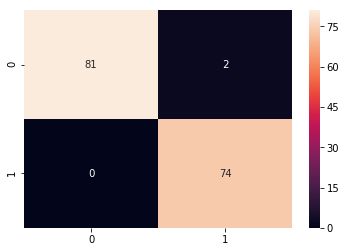

```python
sns.heatmap(metrics.confusion_matrix(y_pred,y_test),annot=True,fmt='2.0f')
```

```python
bag_clf.fit(X_trainval, y_trainval)
print('Train score: {:.2f}'.format(bag_clf.score(X_trainval, y_trainval)))
print('Test score: {:.2f}'.format(bag_clf.score(X_test, y_test)))
```

```
Train score: 0.99
Test score: 0.99
```

```python
log_reg = LogisticRegression(penalty = 'l1', C = 1)
log_reg.fit(X_trainval, y_trainval)
y_pred_tree = log_reg.predict(X_test)

print("Logistic Regression Accuracy:",metrics.accuracy_score(y_test, y_pred_tree))

#Computing classification Report
print("Classification Report:\n", classification_report(y_test, y_pred_tree))
#Plotting confusion matrix
print("Confusion Matrix:")
df = pd.DataFrame(
    confusion_matrix(y_test, y_pred_tree),
    index = [['actual', 'actual'], ['Neg','Pos']],
    columns = [['predicted', 'predicted'], ['Neg', 'Pos']])
print(df)
```

```
Logistic Regression Accuracy: 1.0
Classification Report:
               precision    recall  f1-score   support

           0       1.00      1.00      1.00        81
           1       1.00      1.00      1.00        76

   micro avg       1.00      1.00      1.00       157
   macro avg       1.00      1.00      1.00       157
weighted avg       1.00      1.00      1.00       157

Confusion Matrix:
           predicted
                 Neg Pos
actual Neg        81   0
       Pos         0  76
```

```python
sns.heatmap(metrics.confusion_matrix(logreg_test_pred,y_test),annot=True,fmt='2.0f')
```

[output not shown]

```python
pd.crosstab(y_trainval, logreg_tr_pred)
```

| col_0 RISK | 0 | 1 |
| --- | --- | --- |
| 0 | 241 | 0 |
| 1 | 2 | 226 |

```python
print(log_reg.score(X_trainval, y_trainval))
```

```
0.9957356076759062
```

```python
pd.crosstab(y_test, logreg_test_pred)
```

| col_0 RISK | 0 | 1 |
| --- | --- | --- |
| 0 | 81 | 0 |
| 1 | 0 | 76 |

```python
print(log_reg.score(X_test, y_test))
```

```
1.0
```

```
AUC: 1.000
[1.99999996 0.99999996 0.9999999  0.99999727 0.99999725 0.99999718
 0.9999969  0.99999684 0.99999679 0.99996307 0.99995955 0.99995729
 0.99995624 0.99994955 0.99994882 0.99828248 0.99817236 0.99273996
 0.99230573 0.88596137 0.70965072 0.04249366 0.0423761  0.04205857
 0.04120113 0.04081105 0.02865566 0.01441261 0.0132087 ]
```

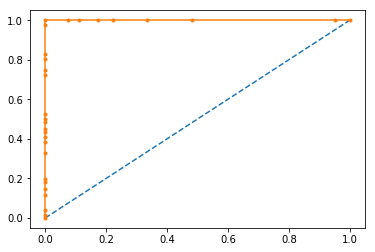

```python
from sklearn.metrics import roc_curve
from sklearn.metrics import roc_auc_score
from matplotlib import pyplot

# predict probabilities
probs = log_reg.predict_proba(X_test)
# keep probabilities for the positive outcome only
probs = probs[:, 1]

# calculate AUC
auc = roc_auc_score(y_test, probs)
print('AUC: %.3f' % auc)

# calculate roc curve
fpr, tpr, thresholds = roc_curve(y_test, probs)
print( thresholds )
# plot no skill
pyplot.plot([0, 1], [0, 1], linestyle='--')
# plot the roc curve for the model
pyplot.plot(fpr, tpr, marker='.')
# show the plot
pyplot.show()
```

## 4. Bagging - K-NN

#### We Perform BAGGING on the new model with the best parameters which results in a Train Score = 0.99 , Test Score = 0.99.

#### AUC of 1.0 , which shows perfect classification.

```python
from sklearn.neighbors import KNeighborsClassifier

train_score_array = []
test_score_array = []

knn = KNeighborsClassifier(3)
knn.fit(X_train, y_train)
train_score_array.append(knn.score(X_trainval, y_trainval))
test_score_array.append(knn.score(X_test, y_test))
```

```python
from sklearn.ensemble import BaggingClassifier
from sklearn.model_selection import GridSearchCV


knn_clf = KNeighborsClassifier(3)
n_estimators_vals = [100, 200, 300, 400, 500]
max_samples_vals = [10, 50, 70, 100, 120, 150, 170, 200]


param_grid = dict(n_estimators=n_estimators_vals, max_samples = max_samples_vals)

knn_bag = BaggingClassifier(knn_clf,bootstrap = True, random_state=0)

grid_search = GridSearchCV(knn_bag, param_grid = dict(n_estimators=n_estimators_vals, max_samples = max_samples_vals), cv=10, return_train_score=True)
grid_search.fit(X_trainval, y_trainval)
print("Best score on validation set: {:.2f}".format(best_score))
print("Best parameters: {}".format(grid_search.best_params_))
print("Best cross-validation score: {:.2f}".format(grid_search.best_score_))
```

```
Best score on validation set: 0.00
Best parameters: {'max_samples': 170, 'n_estimators': 100}
Best cross-validation score: 1.00
```

```python
from sklearn.ensemble import BaggingClassifier


knn_clf = KNeighborsClassifier(3)
knn_bag_clf = BaggingClassifier(knn_clf, n_estimators=100, max_samples=170, bootstrap=True, random_state=0)

knn_bag_clf.fit(X_trainval, y_trainval)
y_predK = bag_clf.predict(X_test)
```

```python
print("KNN Accuracy:",metrics.accuracy_score(y_test, y_predK))

#Computing classification Report
print("Classification Report:\n", classification_report(y_test, y_predK))
#Plotting confusion matrix
print("Confusion Matrix:")
df = pd.DataFrame(
    confusion_matrix(y_test, y_predK),
    index = [['actual', 'actual'], ['Neg','Pos']],
    columns = [['predicted', 'predicted'], ['Neg', 'Pos']])
print(df)
```

```
KNN Accuracy: 0.9872611464968153
Classification Report:
               precision    recall  f1-score   support

           0       0.98      1.00      0.99        81
           1       1.00      0.97      0.99        76

   micro avg       0.99      0.99      0.99       157
   macro avg       0.99      0.99      0.99       157
weighted avg       0.99      0.99      0.99       157

Confusion Matrix:
           predicted
                 Neg Pos
actual Neg        81   0
       Pos         2  74
```

```python
knn_bag_clf.fit(X_trainval, y_trainval)
print('Train score: {:.2f}'.format(bag_clf.score(X_trainval, y_trainval)))
print('Test score: {:.2f}'.format(bag_clf.score(X_test, y_test)))
```

```
Train score: 0.99
Test score: 0.99
```

```python
knnc_tr_pred = knn_bag_clf.predict(X_trainval)
knnc_test_pred = knn_bag_clf.predict(X_test)
print(knnc_tr_pred[4])

print("KNN Accuracy after bagging:",metrics.accuracy_score(y_test, y_predK))

#for train data
print("Train data")
print(" Train data Accuracy score: ", accuracy_score(y_trainval, knnc_tr_pred))
print("Classification Report:\n", classification_report(y_trainval, knnc_tr_pred))
#Plotting confusion matrix
print("Confusion Matrix:")
df = pd.DataFrame(
    confusion_matrix(y_trainval, knnc_tr_pred),
    index = [['actual', 'actual'], ['Neg','Pos']],
    columns = [['predicted', 'predicted'], ['Neg', 'Pos']])
print(df)


# for TEST DATA
print("\nTest data")
print("Test data Accuracy score: ", accuracy_score(y_test, knnc_test_pred))
#Computing classification Report
print("Classification Report:\n", classification_report(y_test, knnc_test_pred))
#Plotting confusion matrix
print("Confusion Matrix:")
df = pd.DataFrame(
    confusion_matrix(y_test, knnc_test_pred),
    index = [['actual', 'actual'], ['Neg','Pos']],
    columns = [['predicted', 'predicted'], ['Neg', 'Pos']])
print(df)
```

```
1
KNN Accuracy after bagging: 0.9872611464968153
Train data
 Train data Accuracy score:  0.997867803837953
Classification Report:
               precision    recall  f1-score   support

           0       1.00      1.00      1.00       241
           1       1.00      1.00      1.00       228

   micro avg       1.00      1.00      1.00       469
   macro avg       1.00      1.00      1.00       469
weighted avg       1.00      1.00      1.00       469

Confusion Matrix:
           predicted
                 Neg  Pos
actual Neg       241    0
       Pos         1  227

Test data
Test data Accuracy score:  0.9936305732484076
Classification Report:
               precision    recall  f1-score   support

           0       0.99      1.00      0.99        81
           1       1.00      0.99      0.99        76

   micro avg       0.99      0.99      0.99       157
   macro avg       0.99      0.99      0.99       157
weighted avg       0.99      0.99      0.99       157

Confusion Matrix:
           predicted
                 Neg Pos
actual Neg        81   0
       Pos         1  75
```

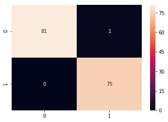

```python
sns.heatmap(metrics.confusion_matrix(knnc_test_pred,y_test),annot=True,fmt='2.0f')
```

```python
from sklearn.metrics import roc_curve
from sklearn.metrics import roc_auc_score
from matplotlib import pyplot

# fit a model
knn_clf.fit(X_trainval,y_trainval)
# predict probabilities
probs = knn_clf.predict_proba(X_test)
# keep probabilities for the positive outcome only
probs = probs[:, 1]

# calculate AUC
auc = roc_auc_score(y_test, probs)
print('AUC: %.3f' % auc)

# calculate roc curve
fpr, tpr, thresholds = roc_curve(y_test, probs)
print( thresholds )
# plot no skill
pyplot.plot([0, 1], [0, 1], linestyle='--')
# plot the roc curve for the model
pyplot.plot(fpr, tpr, marker='.')
# show the plot
pyplot.show()
```

[output not shown]

[output not shown]

```
f1=0.987 auc=1.000 ap=1.000
```

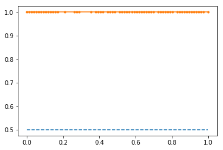

```python
from sklearn.metrics import auc
from sklearn.metrics import average_precision_score
from sklearn.metrics import precision_recall_curve

# predict probabilities
probs = bag_clf.predict_proba(X_test)

# keep probabilities for the positive outcome only
probs = probs[:, 1]

# predict class values
yhat = bag_clf.predict(X_test)

# calculate precision-recall curve
precision, recall, thresholds = precision_recall_curve(y_test, probs)

# calculate F1 score
f1 = f1_score(y_test, yhat)

# calculate precision-recall AUC
auc = auc(recall, precision)
# calculate average precision score
ap = average_precision_score(y_test, probs)
print('f1=%.3f auc=%.3f ap=%.3f' % (f1, auc, ap))
# plot no skill
pyplot.plot([0, 1], [0.5, 0.5], linestyle='--')
# plot the precision-recall curve for the model
pyplot.plot(recall, precision, marker='.')
# show the plot
pyplot.show()
```

#### Its recall and precision is shown below.

```python
from sklearn import svm
from sklearn.svm import SVC
```

```python
svc_clf = SVC(C=1.0, gamma='auto')
n_estimators_vals = [100, 200, 300, 400, 500]
max_samples_vals = [10, 50, 70, 100, 120, 150, 170, 200]


param_grid = dict(n_estimators=n_estimators_vals, max_samples = max_samples_vals)

svc_bag = BaggingClassifier(svc_clf,bootstrap = False, random_state=0)

grid_search = GridSearchCV(svc_bag, param_grid = dict(n_estimators=n_estimators_vals, max_samples = max_samples_vals), cv=10, return_train_score=True)
grid_search.fit(X_trainval, y_trainval)
print("Best score on validation set: {:.2f}".format(best_score))
print("Best parameters: {}".format(grid_search.best_params_))
print("Best cross-validation score: {:.2f}".format(grid_search.best_score_))
```

```
Best score on validation set: 0.00
Best parameters: {'max_samples': 200, 'n_estimators': 100}
Best cross-validation score: 0.98
```

```python
from sklearn.ensemble import BaggingClassifier


svc_clf = SVC(C=1.0, gamma='auto')
svc_bag_clf = BaggingClassifier(svc_clf, n_estimators=100, max_samples=150, bootstrap= False, random_state=0)

svc_bag_clf.fit(X_train, y_train)
y_predsvc = svc_bag_clf.predict(X_test)
```

```python
print("SVC Accuracy:",metrics.accuracy_score(y_test, y_predsvc))

#Computing classification Report
print("Classification Report:\n", classification_report(y_test, y_predsvc))
#Plotting confusion matrix
print("Confusion Matrix:")
df = pd.DataFrame(
    confusion_matrix(y_test, y_predsvc),
    index = [['actual', 'actual'], ['Neg','Pos']],
    columns = [['predicted', 'predicted'], ['Neg', 'Pos']])
print(df)
```

```
SVC Accuracy: 0.9745222929936306
Classification Report:
               precision    recall  f1-score   support

           0       0.95      1.00      0.98        81
           1       1.00      0.95      0.97        76

   micro avg       0.97      0.97      0.97       157
   macro avg       0.98      0.97      0.97       157
weighted avg       0.98      0.97      0.97       157

Confusion Matrix:
           predicted
                 Neg Pos
actual Neg        81   0
       Pos         4  72
```

```python
svc_bag_clf.fit(X_trainval, y_trainval)
print('Train score: {:.2f}'.format(bag_clf.score(X_trainval, y_trainval)))
print('Test score: {:.2f}'.format(bag_clf.score(X_test, y_test)))
```

```
Train score: 0.99
Test score: 0.99
```

```python
svc_tr_pred = svc_bag_clf.predict(X_trainval)
svc_test_pred = svc_bag_clf.predict(X_test)

#print("SVC Accuracy after bagging:",metrics.accuracy_score(y_test, y_predK))

#for train data
print("Train data")
print(" Train data Accuracy score: ", accuracy_score(y_trainval, svc_tr_pred))
print("Classification Report:\n", classification_report(y_trainval, svc_tr_pred))
#Plotting confusion matrix
print("Confusion Matrix:")
df = pd.DataFrame(
    confusion_matrix(y_trainval, svc_tr_pred),
    index = [['actual', 'actual'], ['Neg','Pos']],
    columns = [['predicted', 'predicted'], ['Neg', 'Pos']])
print(df)


# for TEST DATA
print("\nTest data")
print("Test data Accuracy score: ", accuracy_score(y_test, svc_test_pred))
#Computing classification Report
print("Classification Report:\n", classification_report(y_test, svc_test_pred))
#Plotting confusion matrix
print("Confusion Matrix:")
df = pd.DataFrame(
    confusion_matrix(y_test, svc_test_pred),
    index = [['actual', 'actual'], ['Neg','Pos']],
    columns = [['predicted', 'predicted'], ['Neg', 'Pos']])
print(df)
```

```
Train data
 Train data Accuracy score:  0.9808102345415778
Classification Report:
               precision    recall  f1-score   support

           0       0.96      1.00      0.98       241
           1       1.00      0.96      0.98       228

   micro avg       0.98      0.98      0.98       469
   macro avg       0.98      0.98      0.98       469
weighted avg       0.98      0.98      0.98       469

Confusion Matrix:
           predicted
                 Neg  Pos
actual Neg       241    0
       Pos         9  219

Test data
Test data Accuracy score:  0.9745222929936306
Classification Report:
               precision    recall  f1-score   support

           0       0.95      1.00      0.98        81
           1       1.00      0.95      0.97        76

   micro avg       0.97      0.97      0.97       157
   macro avg       0.98      0.97      0.97       157
weighted avg       0.98      0.97      0.97       157

Confusion Matrix:
           predicted
                 Neg Pos
actual Neg        81   0
       Pos         4  72
```

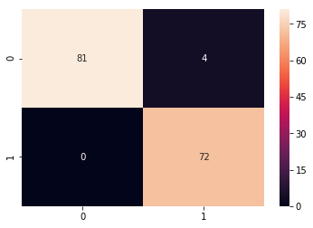

```python
sns.heatmap(metrics.confusion_matrix(svc_test_pred,y_test),annot=True,fmt='2.0f')
```

```
f1=0.973 auc=0.993 ap=0.986
```

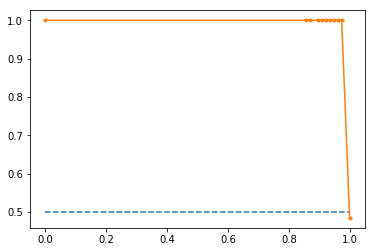

```python
from sklearn.metrics import auc
from sklearn.metrics import average_precision_score
from sklearn.metrics import precision_recall_curve

# predict probabilities
probs = svc_bag_clf.predict_proba(X_test)

# keep probabilities for the positive outcome only
probs = probs[:, 1]

# predict class values
yhat = svc_bag_clf.predict(X_test)

# calculate precision-recall curve
precision, recall, thresholds = precision_recall_curve(y_test, probs)

# calculate F1 score
f1 = f1_score(y_test, yhat)

# calculate precision-recall AUC
auc = auc(recall, precision)
# calculate average precision score
ap = average_precision_score(y_test, probs)
print('f1=%.3f auc=%.3f ap=%.3f' % (f1, auc, ap))
# plot no skill
pyplot.plot([0, 1], [0.5, 0.5], linestyle='--')
# plot the precision-recall curve for the model
pyplot.plot(recall, precision, marker='.')
# show the plot
pyplot.show()
```

## 6. SVC - KERNEL RBF

```python
svc_rbf_clf = SVC(kernel='rbf',C=1.0, gamma=0.5)
n_estimators_vals = [100, 200, 300, 400, 500]
max_samples_vals = [10, 50, 70, 100, 120, 150, 170, 200]

param_grid = dict(n_estimators=n_estimators_vals, max_samples = max_samples_vals)

svcrbf_bag_clf = BaggingClassifier(svc_rbf_clf,bootstrap = False, random_state=0)

grid_search = GridSearchCV(svcrbf_bag_clf , param_grid = dict(n_estimators=n_estimators_vals, max_samples = max_samples_vals), cv=10, return_train_score=True)
grid_search.fit(X_trainval, y_trainval)
print("Best score on validation set: {:.2f}".format(best_score))
print("Best parameters: {}".format(grid_search.best_params_))
print("Best cross-validation score: {:.2f}".format(grid_search.best_score_))
```

```
Best score on validation set: 0.00
Best parameters: {'max_samples': 50, 'n_estimators': 100}
Best cross-validation score: 1.00
```

```python
from sklearn.ensemble import BaggingClassifier


svc_rbf_clf = SVC(kernel='rbf',C=1.0, gamma=0.5)
svcrbf_bag_clf = BaggingClassifier(svc_rbf_clf, n_estimators=100, max_samples=50, bootstrap= False, random_state=0)

svcrbf_bag_clf.fit(X_train, y_train)
y_predrbf = svcrbf_bag_clf.predict(X_test)
```

```python
print("SVC-kernel RBF Accuracy:",metrics.accuracy_score(y_test, y_predrbf))

#Computing classification Report
print("Classification Report:\n", classification_report(y_test, y_predrbf))
#Plotting confusion matrix
print("Confusion Matrix:")
df = pd.DataFrame(
    confusion_matrix(y_test, y_predrbf),
    index = [['actual', 'actual'], ['Neg','Pos']],
    columns = [['predicted', 'predicted'], ['Neg', 'Pos']])
print(df)
```

```
SVC-kernel RBF Accuracy: 1.0
Classification Report:
               precision    recall  f1-score   support

           0       1.00      1.00      1.00        81
           1       1.00      1.00      1.00        76

   micro avg       1.00      1.00      1.00       157
   macro avg       1.00      1.00      1.00       157
weighted avg       1.00      1.00      1.00       157

Confusion Matrix:
           predicted
                 Neg Pos
actual Neg        81   0
       Pos         0  76
```

```python
svcrbf_bag_clf.fit(X_trainval, y_trainval)
print('Train score: {:.2f}'.format(svcrbf_bag_clf.score(X_trainval, y_trainval)))
print('Test score: {:.2f}'.format(svcrbf_bag_clf.score(X_test, y_test)))
```

```
Train score: 1.00
Test score: 1.00
```

```python
svcrbf_tr_pred = svcrbf_bag_clf.predict(X_trainval)
svcrbf_test_pred = svcrbf_bag_clf.predict(X_test)


#for train data
print("Train data")
print(" Train data Accuracy score: ", accuracy_score(y_trainval, svcrbf_tr_pred))
print("Classification Report:\n", classification_report(y_trainval, svcrbf_tr_pred))
#Plotting confusion matrix
print("Confusion Matrix:")
df = pd.DataFrame(
    confusion_matrix(y_trainval, svcrbf_tr_pred),
    index = [['actual', 'actual'], ['Neg','Pos']],
    columns = [['predicted', 'predicted'], ['Neg', 'Pos']])
print(df)


# for TEST DATA
print("\nTest data")
print("Test data Accuracy score: ", accuracy_score(y_test, svcrbf_test_pred))
#Computing classification Report
print("Classification Report:\n", classification_report(y_test, svcrbf_test_pred))
#Plotting confusion matrix
print("Confusion Matrix:")
df = pd.DataFrame(
    confusion_matrix(y_test, svcrbf_test_pred),
    index = [['actual', 'actual'], ['Neg','Pos']],
    columns = [['predicted', 'predicted'], ['Neg', 'Pos']])
print(df)
```

```
Train data
 Train data Accuracy score:  0.997867803837953
Classification Report:
               precision    recall  f1-score   support

           0       1.00      1.00      1.00       241
           1       1.00      1.00      1.00       228

   micro avg       1.00      1.00      1.00       469
   macro avg       1.00      1.00      1.00       469
weighted avg       1.00      1.00      1.00       469

Confusion Matrix:
           predicted
                 Neg  Pos
actual Neg       241    0
       Pos         1  227

Test data
Test data Accuracy score:  1.0
Classification Report:
               precision    recall  f1-score   support

           0       1.00      1.00      1.00        81
           1       1.00      1.00      1.00        76

   micro avg       1.00      1.00      1.00       157
   macro avg       1.00      1.00      1.00       157
weighted avg       1.00      1.00      1.00       157

Confusion Matrix:
           predicted
                 Neg Pos
actual Neg        81   0
       Pos         0  76
```

```python
sns.heatmap(metrics.confusion_matrix(svcrbf_test_pred,y_test),annot=True,fmt='2.0f')
```

[output not shown]

```
f1=0.973 auc=0.993 ap=0.986
```

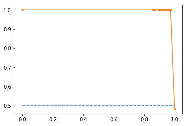

```python
from sklearn.metrics import auc
from sklearn.metrics import average_precision_score
from sklearn.metrics import precision_recall_curve

# predict probabilities
probs = svc_bag_clf.predict_proba(X_test)

# keep probabilities for the positive outcome only
probs = probs[:, 1]

# predict class values
yhat = svc_bag_clf.predict(X_test)

# calculate precision-recall curve
precision, recall, thresholds = precision_recall_curve(y_test, probs)

# calculate F1 score
f1 = f1_score(y_test, yhat)

# calculate precision-recall AUC
auc = auc(recall, precision)
# calculate average precision score
ap = average_precision_score(y_test, probs)
print('f1=%.3f auc=%.3f ap=%.3f' % (f1, auc, ap))
# plot no skill
pyplot.plot([0, 1], [0.5, 0.5], linestyle='--')
# plot the precision-recall curve for the model
pyplot.plot(recall, precision, marker='.')
# show the plot
pyplot.show()
```

## 7. GRADIENT BOOSTING - DECISION TREE

```python
from sklearn.tree import DecisionTreeClassifier
dt_clf = DecisionTreeClassifier(max_depth=4)
dt_clf.fit(X_trainval, y_trainval)
dt_pred = dt_clf.predict(X_trainval)
dt_test_pred = dt_clf.predict(X_test)
```

```python
from sklearn.ensemble import GradientBoostingClassifier
gbrt = GradientBoostingClassifier(random_state=0, max_depth=4)
gbrt.fit(X_trainval, y_trainval)

print("Accuracy on training set: {:.3f}".format(gbrt.score(X_trainval, y_trainval)))
print("Accuracy on test set: {:.3f}".format(gbrt.score(X_test, y_test)))
```

```
Accuracy on training set: 1.000
Accuracy on test set: 1.000
```

```python
gbrt.fit(X_trainval, y_trainval)
```

```
GradientBoostingClassifier(criterion='friedman_mse', init=None,
              learning_rate=0.1, loss='deviance', max_depth=4,
              max_features=None, max_leaf_nodes=None,
              min_impurity_decrease=0.0, min_impurity_split=None,
              min_samples_leaf=1, min_samples_split=2,
              min_weight_fraction_leaf=0.0, n_estimators=100,
              n_iter_no_change=None, presort='auto', random_state=0,
              subsample=1.0, tol=0.0001, validation_fraction=0.1,
              verbose=0, warm_start=False)
```

```python
gbrt_tr_pred = gbrt.predict(X_trainval)
gbrt_test_pred = gbrt.predict(X_test)
```

```python
gbrt_tr_pred = gbrt.predict(X_trainval)
gbrt_test_pred= gbrt.predict(X_test)
```

```python
#for train data
print("Train data")
print(" Train data Accuracy score: ", accuracy_score(y_trainval, dt_pred))
print("Classification Report:\n", classification_report(y_trainval, dt_pred))
#Plotting confusion matrix
print("Confusion Matrix:")
df = pd.DataFrame(
    confusion_matrix(y_trainval, dt_pred),
    index = [['actual', 'actual'], ['Neg','Pos']],
    columns = [['predicted', 'predicted'], ['Neg', 'Pos']])
print(df)


# for TEST DATA
print("\n")
print("\nTest data")
print("Test data Accuracy score: ", accuracy_score(y_test, dt_test_pred))
#Computing classification Report
print("Classification Report:\n", classification_report(y_test, dt_test_pred))
#Plotting confusion matrix
print("Confusion Matrix:")
df = pd.DataFrame(
    confusion_matrix(y_test, dt_test_pred),
    index = [['actual', 'actual'], ['Neg','Pos']],
    columns = [['predicted', 'predicted'], ['Neg', 'Pos']])
print(df)
```

```
Train data
 Train data Accuracy score:  1.0
Classification Report:
               precision    recall  f1-score   support

           0       1.00      1.00      1.00       241
           1       1.00      1.00      1.00       228

   micro avg       1.00      1.00      1.00       469
   macro avg       1.00      1.00      1.00       469
weighted avg       1.00      1.00      1.00       469

Confusion Matrix:
           predicted
                 Neg  Pos
actual Neg       241    0
       Pos         0  228



Test data
Test data Accuracy score:  1.0
Classification Report:
               precision    recall  f1-score   support

           0       1.00      1.00      1.00        81
           1       1.00      1.00      1.00        76

   micro avg       1.00      1.00      1.00       157
   macro avg       1.00      1.00      1.00       157
weighted avg       1.00      1.00      1.00       157

Confusion Matrix:
           predicted
                 Neg Pos
actual Neg        81   0
       Pos         0  76
```

```python
sns.heatmap(metrics.confusion_matrix(dt_test_pred,y_test),annot=True,fmt='2.0f')
```

## 8. ADABOOST CLASSIFIER - LINEAR SVC

```python
from sklearn.svm import LinearSVC

lsvc = LinearSVC(C=1)
```

```python
from sklearn.ensemble import AdaBoostClassifier
lsvc = LinearSVC(C=1)

n_estimators_vals = [100, 200, 300, 400, 500]
learning_rate_vals = [0.01, 0.1, 0.3, 0.5, 1.0]


param_grid = dict(n_estimators=n_estimators_vals, learning_rate = learning_rate_vals)
lsvc_ada = AdaBoostClassifier(lsvc, algorithm="SAMME",random_state=0)
grid_search = GridSearchCV(lsvc_ada, param_grid = dict(n_estimators=n_estimators_vals, learning_rate = learning_rate_vals), cv=10, return_train_score=True)
grid_search.fit(X_trainval, y_trainval)
print("Best score on validation set: {:.2f}".format(best_score))
print("Best parameters: {}".format(grid_search.best_params_))
print("Best cross-validation score: {:.2f}".format(grid_search.best_score_))
```

```
Best score on validation set: 0.00
Best parameters: {'learning_rate': 0.01, 'n_estimators': 100}
Best cross-validation score: 1.00
```

```python
ada_clf = AdaBoostClassifier(LinearSVC(C=1), n_estimators=100, algorithm="SAMME", learning_rate=0.01, random_state=0)
ada_clf.fit(X_trainval, y_trainval)


clf_tr_pred = ada_clf.predict(X_trainval)
clf_test_pred = ada_clf.predict(X_test)
```

```python
#for train data
print("Train data")
print(" Train data Accuracy score: ", accuracy_score(y_trainval, clf_tr_pred))
print("Classification Report:\n", classification_report(y_trainval, clf_tr_pred))
#Plotting confusion matrix
print("Confusion Matrix:")
df = pd.DataFrame(
    confusion_matrix(y_trainval, clf_tr_pred),
    index = [['actual', 'actual'], ['Neg','Pos']],
    columns = [['predicted', 'predicted'], ['Neg', 'Pos']])
print(df)


# for TEST DATA
print("\n")
print("\nTest data")
print("Test data Accuracy score: ", accuracy_score(y_test, clf_test_pred))
#Computing classification Report
print("Classification Report:\n", classification_report(y_test, clf_test_pred))
#Plotting confusion matrix
print("Confusion Matrix:")
df = pd.DataFrame(
    confusion_matrix(y_test, clf_test_pred),
    index = [['actual', 'actual'], ['Neg','Pos']],
    columns = [['predicted', 'predicted'], ['Neg', 'Pos']])
print(df)
```

```
Train data
 Train data Accuracy score:  0.997867803837953
Classification Report:
               precision    recall  f1-score   support

           0       1.00      1.00      1.00       241
           1       1.00      1.00      1.00       228

   micro avg       1.00      1.00      1.00       469
   macro avg       1.00      1.00      1.00       469
weighted avg       1.00      1.00      1.00       469

Confusion Matrix:
           predicted
                 Neg  Pos
actual Neg       241    0
       Pos         1  227



Test data
Test data Accuracy score:  1.0
Classification Report:
               precision    recall  f1-score   support

           0       1.00      1.00      1.00        81
           1       1.00      1.00      1.00        76

   micro avg       1.00      1.00      1.00       157
   macro avg       1.00      1.00      1.00       157
weighted avg       1.00      1.00      1.00       157

Confusion Matrix:
           predicted
                 Neg Pos
actual Neg        81   0
       Pos         0  76
```

```python
sns.heatmap(metrics.confusion_matrix(clf_test_pred,y_test),annot=True,fmt='2.0f')
```

```python
pd.crosstab(y_trainval, clf_tr_pred)
```

| col_0 RISK | 0 | 1 |
| --- | --- | --- |
| 0 | 241 | 0 |
| 1 | 1 | 227 |

```python
pd.crosstab(y_test, clf_test_pred)
```

| col_0 RISK | 0 | 1 |
| --- | --- | --- |
| 0 | 81 | 0 |
| 1 | 0 | 76 |

## 9. SVC KERNEL POLY- ADABOOST

```python
poly_clf = SVC(kernel='poly',C=1.0, degree=1)
```

```python
from sklearn.ensemble import AdaBoostClassifier
poly_clf = SVC(kernel='poly',C=1.0, degree=1)

n_estimators_vals = [100, 200, 300, 400, 500]
learning_rate_vals = [0.01, 0.1, 0.3, 0.5, 1.0]

param_grid = dict(n_estimators=n_estimators_vals, learning_rate = learning_rate_vals)
poly_clf_ada = AdaBoostClassifier(poly_clf, algorithm="SAMME",random_state=0)
grid_search = GridSearchCV(poly_clf_ada , param_grid = dict(n_estimators=n_estimators_vals, learning_rate = learning_rate_vals), cv=10, return_train_score=True)
grid_search.fit(X_trainval, y_trainval)
print("Best parameters: {}".format(grid_search.best_params_))
print("Best cross-validation score: {:.2f}".format(grid_search.best_score_))
```

```
Best parameters: {'learning_rate': 0.5, 'n_estimators': 100}
Best cross-validation score: 0.58
```

```python
poly_clf = SVC(kernel='poly',C=1.0, degree=1)
poly_ada_clf = AdaBoostClassifier(poly_clf, n_estimators=100, algorithm="SAMME", learning_rate=0.5, random_state=0)
poly_ada_clf.fit(X_trainval, y_trainval)


clfpoly_tr_pred = poly_ada_clf.predict(X_trainval)
clfpoly_test_pred = poly_ada_clf.predict(X_test)
```

```python
#for train data
print("Train data")
print(" Train data Accuracy score: ", accuracy_score(y_trainval, clfpoly_tr_pred))
print("Classification Report:\n", classification_report(y_trainval, clfpoly_tr_pred))
#Plotting confusion matrix
print("Confusion Matrix:")
df = pd.DataFrame(
    confusion_matrix(y_trainval, clfpoly_tr_pred),
    index = [['actual', 'actual'], ['Neg','Pos']],
    columns = [['predicted', 'predicted'], ['Neg', 'Pos']])
print(df)


# for TEST DATA
print("\n")
print("\nTest data")
print("Test data Accuracy score: ", accuracy_score(y_test, clfpoly_test_pred))
#Computing classification Report
print("Classification Report:\n", classification_report(y_test, clfpoly_test_pred))
#Plotting confusion matrix
print("Confusion Matrix:")
df = pd.DataFrame(
    confusion_matrix(y_test, clfpoly_test_pred),
    index = [['actual', 'actual'], ['Neg','Pos']],
    columns = [['predicted', 'predicted'], ['Neg', 'Pos']])
print(df)
```

```
Train data
 Train data Accuracy score:  0.5138592750533049
Classification Report:
               precision    recall  f1-score   support

           0       0.51      1.00      0.68       241
           1       0.00      0.00      0.00       228

   micro avg       0.51      0.51      0.51       469
   macro avg       0.26      0.50      0.34       469
weighted avg       0.26      0.51      0.35       469

Confusion Matrix:
           predicted
                 Neg Pos
actual Neg       241   0
       Pos       228   0



Test data
Test data Accuracy score:  0.5159235668789809
Classification Report:
               precision    recall  f1-score   support

           0       0.52      1.00      0.68        81
           1       0.00      0.00      0.00        76

   micro avg       0.52      0.52      0.52       157
   macro avg       0.26      0.50      0.34       157
weighted avg       0.27      0.52      0.35       157

Confusion Matrix:
           predicted
                 Neg Pos
actual Neg        81   0
       Pos        76   0
```

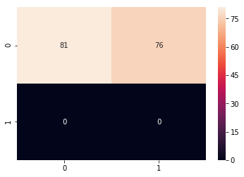

```python
sns.heatmap(metrics.confusion_matrix(clfpoly_test_pred,y_test),annot=True,fmt='2.0f')
```

## DEEP NEURAL NETWORKS

```python
from tensorflow.keras import Sequential
from tensorflow.keras.layers import Dense
from keras.optimizers import SGD
```

```python
#step 1: build model
model1 = Sequential()
#input layer
model1.add(Dense(10, input_dim = 28, activation = 'relu'))
#hidden layers
#output layer
model1.add(Dense(1, activation = 'sigmoid'))

#step 2: make computational graph - compile
opt = SGD(lr=0.01, momentum=0.9)
model1.compile(loss='binary_crossentropy', optimizer = 'adam', metrics=['accuracy'])

#step 3: train the model - fit
model1.fit(X_trainval, y_trainval, epochs = 10, batch_size = 400)
```

```
<tensorflow.python.keras.callbacks.History at 0x12c6a3b00>
```

## PCA

```python
## PCA
from sklearn.decomposition import PCA

pca = PCA().fit(X)
```

```python
# split data into train+validation set and test set
from sklearn.model_selection import cross_val_score
from sklearn.model_selection import GridSearchCV


# split data into train+validation set and test set
X_trainval, X_test, y_trainval, y_test = train_test_split(X, y, random_state=0)

# split train+validation set into training and validation sets
X_train, X_valid, y_train, y_valid = train_test_split(X_trainval, y_trainval, random_state=1)

print("Size of training set: {}   size of validation set: {}   size of test set:"
      " {}\n".format(X_train.shape[0], X_valid.shape[0], X_test.shape[0]))

best_score = 0
```

```
Size of training set: 351   size of validation set: 118   size of test set: 157
```

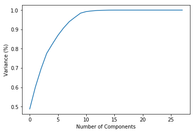

```python
plt.figure()
plt.plot(np.cumsum(pca.explained_variance_ratio_))
plt.xlabel('Number of Components')
plt.ylabel('Variance (%)')
plt.show()
```

```python
pca = PCA(n_components=10)

X_trainval = pca.fit_transform(X_trainval)
X_test = pca.transform(X_test)
```

```python
X_trainval.shape
```

```
(469, 10)
```

```python
X_test.shape
```

```
(157, 10)
```

```python
pca.explained_variance_
```

```
array([0.65195423, 0.1617534 , 0.13172169, 0.115613  , 0.07155135,
       0.06024924, 0.05344001, 0.04211779, 0.03353733, 0.03023716])
```

```python
pca.n_components_
```

```
10
```

```python
pca.explained_variance_ratio_
```

```
array([0.47388799, 0.11757419, 0.09574495, 0.08403598, 0.05200875,
       0.04379355, 0.03884411, 0.03061429, 0.02437738, 0.02197858])
```

```python
np.sum(pca.explained_variance_ratio_)
```

```
0.982859760634868
```

## 1. K-NN after PCA

```python
from sklearn.neighbors import KNeighborsClassifier

train_score_array = []
test_score_array = []

for k in range(1,20):
    knn = KNeighborsClassifier(k)
    knn.fit(X_trainval, y_trainval)
    train_score_array.append(knn.score(X_trainval, y_trainval))
    test_score_array.append(knn.score(X_test, y_test))
```

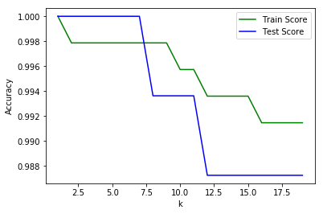

```python
x_axis = range(1,20)
%matplotlib inline
plt.plot(x_axis, train_score_array, label = 'Train Score', c = 'g')
plt.plot(x_axis, test_score_array, label = 'Test Score', c='b')
plt.xlabel('k')
plt.ylabel('Accuracy')
plt.legend()
```

```python
from sklearn.model_selection import cross_val_score , GridSearchCV
from sklearn.neighbors import KNeighborsClassifier




knn = KNeighborsClassifier()


#param_grid = dict(k_range' : [1,3,5,7,9,12,15,17,20])
k_range = [1,3,5,7,9,12,15,17,20]
weights_range = ['uniform','distance']
param_grid = dict(n_neighbors=k_range, weights = weights_range)


#grid_search = GridSearchCV(knn, param_grid, cv=10, return_train_score=True)
grid_search = GridSearchCV(knn, param_grid, cv=10, return_train_score=True)
grid_search.fit(X_trainval, y_trainval)
print("Best parameters: {}".format(grid_search.best_params_))
print("Best cross-validation score: {:.2f}".format(grid_search.best_score_))
```

```
Best parameters: {'n_neighbors': 1, 'weights': 'uniform'}
Best cross-validation score: 1.00
```

```python
from sklearn.neighbors import KNeighborsClassifier

train_score_array = []
test_score_array = []


knn = KNeighborsClassifier(3)
knn.fit(X_trainval, y_trainval)
train_score_array.append(knn.score(X_trainval, y_trainval))
test_score_array.append(knn.score(X_test, y_test))
```

```python
from sklearn.metrics import accuracy_score, precision_score, recall_score, f1_score, roc_auc_score, cohen_kappa_score
```

```python
knn_c_bst_clf = KNeighborsClassifier(n_neighbors=1)

knn_c_bst_clf.fit(X_trainval,y_trainval)

knnc_tr_pred = knn_c_bst_clf.predict(X_trainval)
knnc_test_pred = knn_c_bst_clf.predict(X_test)
print(knnc_tr_pred[4])


#for train data
print("Train data")
print(" Train data Accuracy score: ", accuracy_score(y_trainval, knnc_tr_pred))
print("Classification Report:\n", classification_report(y_trainval, knnc_tr_pred))
#Plotting confusion matrix
print("Confusion Matrix:")
df = pd.DataFrame(
    confusion_matrix(y_trainval, knnc_tr_pred),
    index = [['actual', 'actual'], ['Neg','Pos']],
    columns = [['predicted', 'predicted'], ['Neg', 'Pos']])
print(df)


# for TEST DATA
print("\n")
print("\nTest data")
print("Test data Accuracy score: ", accuracy_score(y_test, knnc_test_pred))
#Computing classification Report
print("Classification Report:\n", classification_report(y_test, knnc_test_pred))
#Plotting confusion matrix
print("Confusion Matrix:")
df = pd.DataFrame(
    confusion_matrix(y_test, knnc_test_pred),
    index = [['actual', 'actual'], ['Neg','Pos']],
    columns = [['predicted', 'predicted'], ['Neg', 'Pos']])
print(df)
```

```
1
Train data
 Train data Accuracy score:  1.0
Classification Report:
               precision    recall  f1-score   support

           0       1.00      1.00      1.00       241
           1       1.00      1.00      1.00       228

   micro avg       1.00      1.00      1.00       469
   macro avg       1.00      1.00      1.00       469
weighted avg       1.00      1.00      1.00       469

Confusion Matrix:
           predicted
                 Neg  Pos
actual Neg       241    0
       Pos         0  228



Test data
Test data Accuracy score:  1.0
Classification Report:
               precision    recall  f1-score   support

           0       1.00      1.00      1.00        81
           1       1.00      1.00      1.00        76

   micro avg       1.00      1.00      1.00       157
   macro avg       1.00      1.00      1.00       157
weighted avg       1.00      1.00      1.00       157

Confusion Matrix:
           predicted
                 Neg Pos
actual Neg        81   0
       Pos         0  76
```

```python
sns.heatmap(metrics.confusion_matrix(knnc_test_pred,y_test),annot=True,fmt='2.0f')
```

```python
pd.crosstab(y_trainval, knnc_tr_pred)
```

| col_0 RISK | 0 | 1 |
| --- | --- | --- |
| 0 | 241 | 0 |
| 1 | 0 | 228 |

```python
pd.crosstab(y_test, knnc_test_pred)
```

| col_0 RISK | 0 | 1 |
| --- | --- | --- |
| 0 | 81 | 0 |
| 1 | 0 | 76 |

```python
from sklearn.metrics import roc_curve
from sklearn.metrics import roc_auc_score
from matplotlib import pyplot

# fit a model
knn_c_bst_clf.fit(X_trainval,y_trainval)
# predict probabilities
probs = knn_c_bst_clf.predict_proba(X_test)
# keep probabilities for the positive outcome only
probs = probs[:, 1]

# calculate AUC
auc = roc_auc_score(y_test, probs)
print('AUC: %.3f' % auc)

# calculate roc curve
fpr, tpr, thresholds = roc_curve(y_test, probs)
print( thresholds )
# plot no skill
pyplot.plot([0, 1], [0, 1], linestyle='--')
# plot the roc curve for the model
pyplot.plot(fpr, tpr, marker='.')
# show the plot
pyplot.show()
```

```
AUC: 1.000
[2. 1. 0.]
```

```
f1=1.000 auc=1.000 ap=1.000
```

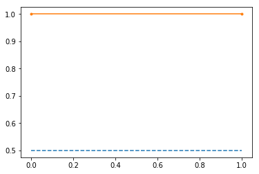

```python
from sklearn.metrics import auc
from sklearn.metrics import average_precision_score
from sklearn.metrics import precision_recall_curve

# predict probabilities
probs = knn_c_bst_clf.predict_proba(X_test)

# keep probabilities for the positive outcome only
probs = probs[:, 1]

# predict class values
yhat = knn_c_bst_clf.predict(X_test)

# calculate precision-recall curve
precision, recall, thresholds = precision_recall_curve(y_test, probs)

# calculate F1 score
f1 = f1_score(y_test, yhat)

# calculate precision-recall AUC
auc = auc(recall, precision)
# calculate average precision score
ap = average_precision_score(y_test, probs)
print('f1=%.3f auc=%.3f ap=%.3f' % (f1, auc, ap))
# plot no skill
pyplot.plot([0, 1], [0.5, 0.5], linestyle='--')
# plot the precision-recall curve for the model
pyplot.plot(recall, precision, marker='.')
# show the plot
pyplot.show()
```

## 2. LOGISTIC REGRESSION after PCA

```python
from sklearn.linear_model import LogisticRegression

c_range = [0.001, 0.01, 0.1, 1, 10, 100, 1000]
train_score_l1 = []
train_score_l2 = []
test_score_l1 = []
test_score_l2 = []

for c in c_range:
    log_l1 = LogisticRegression(penalty = 'l1', C = c)
    log_l2 = LogisticRegression(penalty = 'l2', C = c)
    log_l1.fit(X_trainval, y_trainval)
    log_l2.fit(X_trainval, y_trainval)
    train_score_l1.append(log_l1.score(X_trainval, y_trainval))
    train_score_l2.append(log_l2.score(X_trainval, y_trainval))
    test_score_l1.append(log_l1.score(X_test, y_test))
    test_score_l2.append(log_l2.score(X_test, y_test))
```

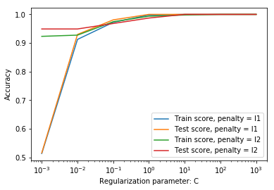

```python
import matplotlib.pyplot as plt
%matplotlib inline

plt.plot(c_range, train_score_l1, label = 'Train score, penalty = l1')
plt.plot(c_range, test_score_l1, label = 'Test score, penalty = l1')
plt.plot(c_range, train_score_l2, label = 'Train score, penalty = l2')
plt.plot(c_range, test_score_l2, label = 'Test score, penalty = l2')
plt.legend()
plt.xlabel('Regularization parameter: C')
plt.ylabel('Accuracy')
plt.xscale('log')
```

```python
from sklearn.linear_model import LogisticRegression

c_range = [0.001, 0.01, 0.1, 1, 10, 100, 1000]
penalty_mod = ['l1','l2']

log_reg = LogisticRegression()

#create a parameter grid: map the parameter names to the values that should be searched
param_grid = dict(penalty=penalty_mod,C=c_range)
print(param_grid)

#instantiation of the grid
log_reg_grid = GridSearchCV(log_reg,param_grid, cv=10, scoring='accuracy')

# fitting the grid
log_reg_grid.fit(X, y)
```

```
{'penalty': ['l1', 'l2'], 'C': [0.001, 0.01, 0.1, 1, 10, 100, 1000]}
```

```
GridSearchCV(cv=10, error_score='raise-deprecating',
       estimator=LogisticRegression(C=1.0, class_weight=None, dual=False, fit_intercept=True,
          intercept_scaling=1, max_iter=100, multi_class='warn',
          n_jobs=None, penalty='l2', random_state=None, solver='warn',
          tol=0.0001, verbose=0, warm_start=False),
       fit_params=None, iid='warn', n_jobs=None,
       param_grid={'penalty': ['l1', 'l2'], 'C': [0.001, 0.01, 0.1, 1, 10, 100, 1000]},
       pre_dispatch='2*n_jobs', refit=True, return_train_score='warn',
       scoring='accuracy', verbose=0)
```

```python
scores = cross_val_score(log_reg, X, y,cv=10) # input arguments followed by X and Y
print("Cross-validation scores: {}".format(scores))
```

```
Cross-validation scores: [1.         0.984375   1.         1.         1.         1.
 0.98387097 1.         1.         0.83870968]
```

```python
log_reg = LogisticRegression(penalty = 'l2', C = 1)
log_reg.fit(X_trainval, y_trainval)

print(log_reg.score(X_trainval, y_trainval))
print(log_reg.score(X_test, y_test))


logreg_tr_pred = log_reg.predict(X_trainval)
logreg_test_pred = log_reg.predict(X_test)
```

```
0.9936034115138592
0.9872611464968153
```

```python
pd.crosstab(y_trainval, logreg_tr_pred)
```

| col_0 RISK | 0 | 1 |
| --- | --- | --- |
| 0 | 241 | 0 |
| 1 | 3 | 225 |

```python
print(log_reg.score(X_trainval, y_trainval))
```

```
0.9936034115138592
```

```python
pd.crosstab(y_test, logreg_test_pred)
```

| col_0 RISK | 0 | 1 |
| --- | --- | --- |
| 0 | 81 | 0 |
| 1 | 2 | 74 |

```python
print(log_reg.score(X_test, y_test))
```

```
0.9872611464968153
```

```python
from sklearn.metrics import classification_report
report = classification_report(y_test, logreg_test_pred)
print(report)
```

```
              precision    recall  f1-score   support

           0       0.98      1.00      0.99        81
           1       1.00      0.97      0.99        76

   micro avg       0.99      0.99      0.99       157
   macro avg       0.99      0.99      0.99       157
weighted avg       0.99      0.99      0.99       157
```

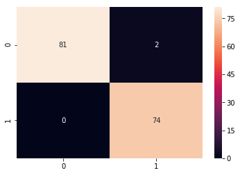

```python
sns.heatmap(metrics.confusion_matrix(logreg_test_pred,y_test),annot=True,fmt='2.0f')
```

```python
from sklearn.metrics import accuracy_score

#for train data
print("Train data")
print(" Train data Accuracy score: ", accuracy_score(y_trainval, logreg_tr_pred))
print("Classification Report:\n", classification_report(y_trainval, logreg_tr_pred))
#Plotting confusion matrix
print("Confusion Matrix:")
df = pd.DataFrame(
    confusion_matrix(y_trainval, logreg_tr_pred),
    index = [['actual', 'actual'], ['Neg','Pos']],
    columns = [['predicted', 'predicted'], ['Neg', 'Pos']])
print(df)


# for TEST DATA
print("\n")
print("\nTest data")
print("Test data Accuracy score: ", accuracy_score(y_test, logreg_test_pred))
#Computing classification Report
print("Classification Report:\n", classification_report(y_test, logreg_test_pred))
#Plotting confusion matrix
print("Confusion Matrix:")
df = pd.DataFrame(
    confusion_matrix(y_test, logreg_test_pred),
    index = [['actual', 'actual'], ['Neg','Pos']],
    columns = [['predicted', 'predicted'], ['Neg', 'Pos']])
print(df)
```

```
Train data
 Train data Accuracy score:  0.9936034115138592
Classification Report:
               precision    recall  f1-score   support

           0       0.99      1.00      0.99       241
           1       1.00      0.99      0.99       228

   micro avg       0.99      0.99      0.99       469
   macro avg       0.99      0.99      0.99       469
weighted avg       0.99      0.99      0.99       469

Confusion Matrix:
           predicted
                 Neg  Pos
actual Neg       241    0
       Pos         3  225



Test data
Test data Accuracy score:  0.9872611464968153
Classification Report:
               precision    recall  f1-score   support

           0       0.98      1.00      0.99        81
           1       1.00      0.97      0.99        76

   micro avg       0.99      0.99      0.99       157
   macro avg       0.99      0.99      0.99       157
weighted avg       0.99      0.99      0.99       157

Confusion Matrix:
           predicted
                 Neg Pos
actual Neg        81   0
       Pos         2  74
```

```
AUC: 1.000
[1.99999316 0.99999316 0.35667142 0.02871102 0.0286869  0.02832757
 0.02813376 0.02696169 0.02615027 0.02493556]
```

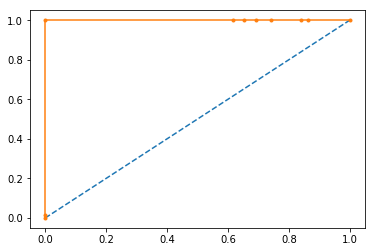

```python
from sklearn.metrics import roc_curve
from sklearn.metrics import roc_auc_score
from matplotlib import pyplot

# predict probabilities
probs = log_reg.predict_proba(X_test)
# keep probabilities for the positive outcome only
probs = probs[:, 1]

# calculate AUC
auc = roc_auc_score(y_test, probs)
print('AUC: %.3f' % auc)

# calculate roc curve
fpr, tpr, thresholds = roc_curve(y_test, probs)
print( thresholds )
# plot no skill
pyplot.plot([0, 1], [0, 1], linestyle='--')
# plot the roc curve for the model
pyplot.plot(fpr, tpr, marker='.')
# show the plot
pyplot.show()
```

```
f1=0.987 auc=1.000 ap=1.000
```

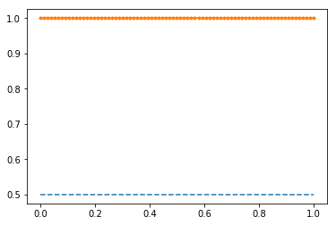

```python
from sklearn.metrics import auc
from sklearn.metrics import average_precision_score
from sklearn.metrics import precision_recall_curve

# predict probabilities
probs = log_reg.predict_proba(X_test)

# keep probabilities for the positive outcome only
probs = probs[:, 1]

# predict class values
y_prd_class_val = log_reg.predict(X_test)

# calculate precision-recall curve
precision, recall, thresholds = precision_recall_curve(y_test, probs)

# calculate F1 score
f1 = f1_score(y_test, y_prd_class_val)

# calculate precision-recall AUC
auc = auc(recall, precision)
# calculate average precision score
ap = average_precision_score(y_test, probs)
print('f1=%.3f auc=%.3f ap=%.3f' % (f1, auc, ap))
# plot no skill
pyplot.plot([0, 1], [0.5, 0.5], linestyle='--')
# plot the precision-recall curve for the model
pyplot.plot(recall, precision, marker='.')
# show the plot
pyplot.show()
```

## 3. LINEAR SVC after PCA

```python
from sklearn.svm import LinearSVC
```

```python
c_range= [0.001, 0.01, 0.1, 1, 10, 100]

param_grid = dict(C=c_range)
print("Parameter grid:\n{}".format(param_grid))
```

```
Parameter grid:
{'C': [0.001, 0.01, 0.1, 1, 10, 100]}
```

```python
clf = LinearSVC()
linearsvc_grid_search = GridSearchCV(estimator=clf, param_grid = dict(C=c_range)   ,n_jobs=-1)
linearsvc_grid_search.fit(X, y)
```

```
GridSearchCV(cv='warn', error_score='raise-deprecating',
       estimator=LinearSVC(C=1.0, class_weight=None, dual=True, fit_intercept=True,
     intercept_scaling=1, loss='squared_hinge', max_iter=1000,
     multi_class='ovr', penalty='l2', random_state=None, tol=0.0001,
     verbose=0),
       fit_params=None, iid='warn', n_jobs=-1,
       param_grid={'C': [0.001, 0.01, 0.1, 1, 10, 100]},
       pre_dispatch='2*n_jobs', refit=True, return_train_score='warn',
       scoring=None, verbose=0)
```

```python
linearsvc_grid_search.best_params_
```

```
{'C': 1}
```

```python
clf_best = LinearSVC(C=1)
```

```python
clf_best.fit(X_trainval, y_trainval)

clf_tr_pred = clf_best.predict(X_trainval)
clf_test_pred = clf_best.predict(X_test)
```

```python
#for train data
print("Train data")
print(" Train data Accuracy score: ", accuracy_score(y_trainval, clf_tr_pred))
print("Classification Report:\n", classification_report(y_trainval, clf_tr_pred))
#Plotting confusion matrix
print("Confusion Matrix:")
df = pd.DataFrame(
    confusion_matrix(y_trainval, clf_tr_pred),
    index = [['actual', 'actual'], ['Neg','Pos']],
    columns = [['predicted', 'predicted'], ['Neg', 'Pos']])
print(df)


# for TEST DATA
print("\n")
print("\nTest data")
print("Test data Accuracy score: ", accuracy_score(y_test, clf_test_pred))
#Computing classification Report
print("Classification Report:\n", classification_report(y_test, clf_test_pred))
#Plotting confusion matrix
print("Confusion Matrix:")
df = pd.DataFrame(
    confusion_matrix(y_test, clf_test_pred),
    index = [['actual', 'actual'], ['Neg','Pos']],
    columns = [['predicted', 'predicted'], ['Neg', 'Pos']])
print(df)
```

```
Train data
 Train data Accuracy score:  0.997867803837953
Classification Report:
               precision    recall  f1-score   support

           0       1.00      1.00      1.00       241
           1       1.00      1.00      1.00       228

   micro avg       1.00      1.00      1.00       469
   macro avg       1.00      1.00      1.00       469
weighted avg       1.00      1.00      1.00       469

Confusion Matrix:
           predicted
                 Neg  Pos
actual Neg       241    0
       Pos         1  227



Test data
Test data Accuracy score:  1.0
Classification Report:
               precision    recall  f1-score   support

           0       1.00      1.00      1.00        81
           1       1.00      1.00      1.00        76

   micro avg       1.00      1.00      1.00       157
   macro avg       1.00      1.00      1.00       157
weighted avg       1.00      1.00      1.00       157

Confusion Matrix:
           predicted
                 Neg Pos
actual Neg        81   0
       Pos         0  76
```

```python
pd.crosstab(y_trainval, clf_tr_pred)
```

| col_0 RISK | 0 | 1 |
| --- | --- | --- |
| 0 | 241 | 0 |
| 1 | 1 | 227 |

```python
pd.crosstab(y_test, clf_test_pred)
```

| col_0 RISK | 0 | 1 |
| --- | --- | --- |
| 0 | 81 | 0 |
| 1 | 0 | 76 |

```python
sns.heatmap(metrics.confusion_matrix(clf_test_pred,y_test),annot=True,fmt='2.0f')
```

## 4. SVC LINEAR KERNEL after PCA

```python
from sklearn import svm
from sklearn.svm import SVC
from sklearn.model_selection import cross_val_score , GridSearchCV

c_range= [0.001, 0.01, 0.1, 1, 10, 100]

param_grid = dict(C=c_range)
print("Parameter grid:\n{}".format(param_grid))
```

```
Parameter grid:
{'C': [0.001, 0.01, 0.1, 1, 10, 100]}
```

```python
svc = SVC(kernel='linear')
grid_search = GridSearchCV(estimator=svc, param_grid = dict(C=c_range) ,n_jobs=-1)
grid_search.fit(X, y)
```

```
GridSearchCV(cv='warn', error_score='raise-deprecating',
       estimator=SVC(C=1.0, cache_size=200, class_weight=None, coef0=0.0,
  decision_function_shape='ovr', degree=3, gamma='auto_deprecated',
  kernel='linear', max_iter=-1, probability=False, random_state=None,
  shrinking=True, tol=0.001, verbose=False),
       fit_params=None, iid='warn', n_jobs=-1,
       param_grid={'C': [0.001, 0.01, 0.1, 1, 10, 100]},
       pre_dispatch='2*n_jobs', refit=True, return_train_score='warn',
       scoring=None, verbose=0)
```

```python
grid_search.best_score_
```

```
0.9984025559105432
```

```python
grid_search.best_params_
```

```
{'C': 10}
```

```python
svc_best = SVC(C=10, gamma='auto',probability=True)
```

```python
svc_best.fit(X_trainval, y_trainval)

svc_tr_pred = svc_best.predict(X_trainval)
svc_test_pred = svc_best.predict(X_test)
```

```python
#for train data
print("Train data")
print(" Train data Accuracy score: ", accuracy_score(y_trainval, svc_tr_pred))
print("Classification Report:\n", classification_report(y_trainval, svc_tr_pred))
#Plotting confusion matrix
print("Confusion Matrix:")
df = pd.DataFrame(
    confusion_matrix(y_trainval, svc_tr_pred),
    index = [['actual', 'actual'], ['Neg','Pos']],
    columns = [['predicted', 'predicted'], ['Neg', 'Pos']])
print(df)


# for TEST DATA
print("\n")
print("\nTest data")
print("Test data Accuracy score: ", accuracy_score(y_test, svc_test_pred))
#Computing classification Report
print("Classification Report:\n", classification_report(y_test, svc_test_pred))
#Plotting confusion matrix
print("Confusion Matrix:")
df = pd.DataFrame(
    confusion_matrix(y_test, svc_test_pred),
    index = [['actual', 'actual'], ['Neg','Pos']],
    columns = [['predicted', 'predicted'], ['Neg', 'Pos']])
print(df)
```

```
Train data
 Train data Accuracy score:  0.997867803837953
Classification Report:
               precision    recall  f1-score   support

           0       1.00      1.00      1.00       241
           1       1.00      1.00      1.00       228

   micro avg       1.00      1.00      1.00       469
   macro avg       1.00      1.00      1.00       469
weighted avg       1.00      1.00      1.00       469

Confusion Matrix:
           predicted
                 Neg  Pos
actual Neg       241    0
       Pos         1  227



Test data
Test data Accuracy score:  1.0
Classification Report:
               precision    recall  f1-score   support

           0       1.00      1.00      1.00        81
           1       1.00      1.00      1.00        76

   micro avg       1.00      1.00      1.00       157
   macro avg       1.00      1.00      1.00       157
weighted avg       1.00      1.00      1.00       157

Confusion Matrix:
           predicted
                 Neg Pos
actual Neg        81   0
       Pos         0  76
```

```python
pd.crosstab(y_trainval, svc_tr_pred)
```

| col_0 RISK | 0 | 1 |
| --- | --- | --- |
| 0 | 241 | 0 |
| 1 | 1 | 227 |

```python
pd.crosstab(y_test, svc_test_pred)
```

| col_0 RISK | 0 | 1 |
| --- | --- | --- |
| 0 | 81 | 0 |
| 1 | 0 | 76 |

```python
sns.heatmap(metrics.confusion_matrix(svc_test_pred,y_test),annot=True,fmt='2.0f')
```

```
AUC: 1.000
[2.         1.         0.94523259 0.01022565 0.01022469 0.00993171
 0.00992165 0.00968178 0.00967799 0.0083366 ]
```

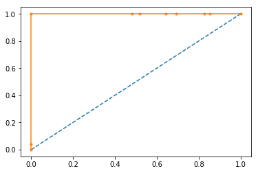

```python
### ROC curve
from sklearn.metrics import roc_curve
from sklearn.metrics import roc_auc_score
from matplotlib import pyplot

# predict probabilities
probs = svc_best.predict_proba(X_test)
# keep probabilities for the positive outcome only
probs = probs[:, 1]

# calculate AUC
auc = roc_auc_score(y_test, probs)
print('AUC: %.3f' % auc)

# calculate roc curve
fpr, tpr, thresholds = roc_curve(y_test, probs)
print( thresholds )
# plot no skill
pyplot.plot([0, 1], [0, 1], linestyle='--')
# plot the roc curve for the model
pyplot.plot(fpr, tpr, marker='.')
# show the plot
pyplot.show()
```

## 5. SVC KERNEL RBF after PCA

```python
#from mlxtend.plotting import plot_decision_regions
from sklearn import svm
from sklearn.svm import SVC
from sklearn.model_selection import cross_val_score , GridSearchCV

c_range= [0.001, 0.01, 0.1, 1, 10, 100]
gamma_range=[0.001, 0.05,0.07,0.03,0.01,0.5,0.3, 0.1, 1, 10, 100]

param_grid = dict(C=c_range, gamma=gamma_range)
print("Parameter grid:\n{}".format(param_grid))
```

```
Parameter grid:
{'C': [0.001, 0.01, 0.1, 1, 10, 100], 'gamma': [0.001, 0.05, 0.07, 0.03, 0.01, 0.5, 0.3, 0.1, 1, 10, 100]}
```

```python
svc = SVC(kernel='rbf')
grid_search = GridSearchCV(estimator=svc, param_grid = dict(C=c_range,gamma=gamma_range) ,n_jobs=-1)
grid_search.fit(X, y)
```

```
GridSearchCV(cv='warn', error_score='raise-deprecating',
       estimator=SVC(C=1.0, cache_size=200, class_weight=None, coef0=0.0,
  decision_function_shape='ovr', degree=3, gamma='auto_deprecated',
  kernel='rbf', max_iter=-1, probability=False, random_state=None,
  shrinking=True, tol=0.001, verbose=False),
       fit_params=None, iid='warn', n_jobs=-1,
       param_grid={'C': [0.001, 0.01, 0.1, 1, 10, 100], 'gamma': [0.001, 0.05, 0.07, 0.03, 0.01, 0.5, 0.3, 0.1, 1, 10, 100]},
       pre_dispatch='2*n_jobs', refit=True, return_train_score='warn',
       scoring=None, verbose=0)
```

```python
grid_search.best_score_
```

```
0.9984025559105432
```

```python
grid_search.best_params_
```

```
{'C': 0.1, 'gamma': 0.5}
```

```python
svc_best_rbf = SVC(kernel='rbf',C=1.0, gamma=0.5)
```

```python
svc_best_rbf.fit(X_trainval, y_trainval)

svc_rbf_tr_pred = svc_best_rbf.predict(X_trainval)
svc_rbf_test_pred = svc_best_rbf.predict(X_test)
```

```python
#for train data
print("Train data")
print(" Train data Accuracy score: ", accuracy_score(y_trainval, svc_rbf_tr_pred))
print("Classification Report:\n", classification_report(y_trainval, svc_rbf_tr_pred))
#Plotting confusion matrix
print("Confusion Matrix:")
df = pd.DataFrame(
    confusion_matrix(y_trainval, svc_rbf_tr_pred),
    index = [['actual', 'actual'], ['Neg','Pos']],
    columns = [['predicted', 'predicted'], ['Neg', 'Pos']])
print(df)


# for TEST DATA
print("\n")
print("\nTest data")
print("Test data Accuracy score: ", accuracy_score(y_test, svc_rbf_test_pred))
#Computing classification Report
print("Classification Report:\n", classification_report(y_test, svc_rbf_test_pred))
#Plotting confusion matrix
print("Confusion Matrix:")
df = pd.DataFrame(
    confusion_matrix(y_test, svc_rbf_test_pred),
    index = [['actual', 'actual'], ['Neg','Pos']],
    columns = [['predicted', 'predicted'], ['Neg', 'Pos']])
print(df)
```

```
Train data
 Train data Accuracy score:  0.997867803837953
Classification Report:
               precision    recall  f1-score   support

           0       1.00      1.00      1.00       241
           1       1.00      1.00      1.00       228

   micro avg       1.00      1.00      1.00       469
   macro avg       1.00      1.00      1.00       469
weighted avg       1.00      1.00      1.00       469

Confusion Matrix:
           predicted
                 Neg  Pos
actual Neg       241    0
       Pos         1  227



Test data
Test data Accuracy score:  1.0
Classification Report:
               precision    recall  f1-score   support

           0       1.00      1.00      1.00        81
           1       1.00      1.00      1.00        76

   micro avg       1.00      1.00      1.00       157
   macro avg       1.00      1.00      1.00       157
weighted avg       1.00      1.00      1.00       157

Confusion Matrix:
           predicted
                 Neg Pos
actual Neg        81   0
       Pos         0  76
```

```python
pd.crosstab(y_trainval, svc_rbf_tr_pred)
```

| col_0 RISK | 0 | 1 |
| --- | --- | --- |
| 0 | 241 | 0 |
| 1 | 1 | 227 |

```python
pd.crosstab(y_test, svc_rbf_test_pred)
```

| col_0 RISK | 0 | 1 |
| --- | --- | --- |
| 0 | 81 | 0 |
| 1 | 0 | 76 |

```python
sns.heatmap(metrics.confusion_matrix(svc_rbf_test_pred,y_test),annot=True,fmt='2.0f')
```

## 6. SVC KERNEL POLY after PCA

```python
from sklearn import svm
from sklearn.svm import SVC
from sklearn.model_selection import cross_val_score , GridSearchCV


c_range= [0.001, 0.01, 0.1, 1, 10, 100]
degree_range=[1,2,3,4]

param_grid = dict(C=c_range, degree = degree_range)
print("Parameter grid:\n{}".format(param_grid))
```

```
Parameter grid:
{'C': [0.001, 0.01, 0.1, 1, 10, 100], 'degree': [1, 2, 3, 4]}
```

```python
svc = SVC(kernel='poly')
grid_search = GridSearchCV(estimator=svc, param_grid = dict(C=c_range,degree = degree_range) ,n_jobs=-1)
grid_search.fit(X, y)
```

```
GridSearchCV(cv='warn', error_score='raise-deprecating',
       estimator=SVC(C=1.0, cache_size=200, class_weight=None, coef0=0.0,
  decision_function_shape='ovr', degree=3, gamma='auto_deprecated',
  kernel='poly', max_iter=-1, probability=False, random_state=None,
  shrinking=True, tol=0.001, verbose=False),
       fit_params=None, iid='warn', n_jobs=-1,
       param_grid={'C': [0.001, 0.01, 0.1, 1, 10, 100], 'degree': [1, 2, 3, 4]},
       pre_dispatch='2*n_jobs', refit=True, return_train_score='warn',
       scoring=None, verbose=0)
```

```python
grid_search.best_score_
```

```
0.9984025559105432
```

```python
grid_search.best_params_
```

```
{'C': 100, 'degree': 1}
```

```python
svc_best_poly = SVC(kernel='poly',C=100, degree=1)
```

```python
svc_best_poly.fit(X_trainval, y_trainval)

svc_poly_tr_pred = svc_best_poly.predict(X_trainval)
svc_poly_test_pred = svc_best_poly.predict(X_test)
```

```python
#for train data
print("Train data")
print(" Train data Accuracy score: ", accuracy_score(y_trainval, svc_poly_tr_pred))
print("Classification Report:\n", classification_report(y_trainval, svc_poly_tr_pred))
#Plotting confusion matrix
print("Confusion Matrix:")
df = pd.DataFrame(
    confusion_matrix(y_trainval, svc_poly_tr_pred),
    index = [['actual', 'actual'], ['Neg','Pos']],
    columns = [['predicted', 'predicted'], ['Neg', 'Pos']])
print(df)


# for TEST DATA
print("\n")
print("\nTest data")
print("Test data Accuracy score: ", accuracy_score(y_test, svc_poly_test_pred))
#Computing classification Report
print("Classification Report:\n", classification_report(y_test, svc_poly_test_pred))
#Plotting confusion matrix
print("Confusion Matrix:")
df = pd.DataFrame(
    confusion_matrix(y_test, svc_poly_test_pred),
    index = [['actual', 'actual'], ['Neg','Pos']],
    columns = [['predicted', 'predicted'], ['Neg', 'Pos']])
print(df)
```

```
Train data
 Train data Accuracy score:  1.0
Classification Report:
               precision    recall  f1-score   support

           0       1.00      1.00      1.00       241
           1       1.00      1.00      1.00       228

   micro avg       1.00      1.00      1.00       469
   macro avg       1.00      1.00      1.00       469
weighted avg       1.00      1.00      1.00       469

Confusion Matrix:
           predicted
                 Neg  Pos
actual Neg       241    0
       Pos         0  228



Test data
Test data Accuracy score:  1.0
Classification Report:
               precision    recall  f1-score   support

           0       1.00      1.00      1.00        81
           1       1.00      1.00      1.00        76

   micro avg       1.00      1.00      1.00       157
   macro avg       1.00      1.00      1.00       157
weighted avg       1.00      1.00      1.00       157

Confusion Matrix:
           predicted
                 Neg Pos
actual Neg        81   0
       Pos         0  76
```

```python
pd.crosstab(y_trainval, svc_poly_tr_pred)
```

| col_0 RISK | 0 | 1 |
| --- | --- | --- |
| 0 | 241 | 0 |
| 1 | 0 | 228 |

```python
pd.crosstab(y_test, svc_rbf_test_pred)
```

| col_0 RISK | 0 | 1 |
| --- | --- | --- |
| 0 | 81 | 0 |
| 1 | 0 | 76 |

```python
sns.heatmap(metrics.confusion_matrix(svc_poly_test_pred,y_test),annot=True,fmt='2.0f')
```

## 7. DECISION TREE after PCA

```python
from sklearn.tree import DecisionTreeClassifier

dt = DecisionTreeClassifier()
param_grid = dict(max_depth=[4,6,8,10])

gs_dt = GridSearchCV(dt, param_grid=param_grid, cv=10, scoring='accuracy')
gs_dt.fit(X_trainval, y_trainval)
```

```
GridSearchCV(cv=10, error_score='raise-deprecating',
       estimator=DecisionTreeClassifier(class_weight=None, criterion='gini', max_depth=None,
            max_features=None, max_leaf_nodes=None,
            min_impurity_decrease=0.0, min_impurity_split=None,
            min_samples_leaf=1, min_samples_split=2,
            min_weight_fraction_leaf=0.0, presort=False, random_state=None,
            splitter='best'),
       fit_params=None, iid='warn', n_jobs=None,
       param_grid={'max_depth': [4, 6, 8, 10]}, pre_dispatch='2*n_jobs',
       refit=True, return_train_score='warn', scoring='accuracy',
       verbose=0)
```

```python
gs_dt.best_score_
```

```
1.0
```

```python
gs_dt.best_params_
```

```
{'max_depth': 4}
```

```python
dt_best = DecisionTreeClassifier(max_depth=4)
dt_best.fit(X_trainval, y_trainval)
dt_pred = dt_best.predict(X_trainval)
dt_test_pred = dt_best.predict(X_test)
```

```python
#for train data
print("Train data")
print(" Train data Accuracy score: ", accuracy_score(y_trainval, dt_pred))
print("Classification Report:\n", classification_report(y_trainval, dt_pred))
#Plotting confusion matrix
print("Confusion Matrix:")
df = pd.DataFrame(
    confusion_matrix(y_trainval, dt_pred),
    index = [['actual', 'actual'], ['Neg','Pos']],
    columns = [['predicted', 'predicted'], ['Neg', 'Pos']])
print(df)


# for TEST DATA
print("\n")
print("\nTest data")
print("Test data Accuracy score: ", accuracy_score(y_test, dt_test_pred))
#Computing classification Report
print("Classification Report:\n", classification_report(y_test, dt_test_pred))
#Plotting confusion matrix
print("Confusion Matrix:")
df = pd.DataFrame(
    confusion_matrix(y_test, dt_test_pred),
    index = [['actual', 'actual'], ['Neg','Pos']],
    columns = [['predicted', 'predicted'], ['Neg', 'Pos']])
print(df)
```

```
Train data
 Train data Accuracy score:  1.0
Classification Report:
               precision    recall  f1-score   support

           0       1.00      1.00      1.00       241
           1       1.00      1.00      1.00       228

   micro avg       1.00      1.00      1.00       469
   macro avg       1.00      1.00      1.00       469
weighted avg       1.00      1.00      1.00       469

Confusion Matrix:
           predicted
                 Neg  Pos
actual Neg       241    0
       Pos         0  228



Test data
Test data Accuracy score:  1.0
Classification Report:
               precision    recall  f1-score   support

           0       1.00      1.00      1.00        81
           1       1.00      1.00      1.00        76

   micro avg       1.00      1.00      1.00       157
   macro avg       1.00      1.00      1.00       157
weighted avg       1.00      1.00      1.00       157

Confusion Matrix:
           predicted
                 Neg Pos
actual Neg        81   0
       Pos         0  76
```

```python
pd.crosstab(y_trainval, dt_pred)
```

| col_0 RISK | 0 | 1 |
| --- | --- | --- |
| 0 | 241 | 0 |
| 1 | 0 | 228 |

```python
pd.crosstab(y_test, dt_test_pred)
```

| col_0 RISK | 0 | 1 |
| --- | --- | --- |
| 0 | 81 | 0 |
| 1 | 0 | 76 |

```python
sns.heatmap(metrics.confusion_matrix(dt_test_pred,y_test),annot=True,fmt='2.0f')
```

```python
### ROC curve
from sklearn.metrics import roc_curve
from sklearn.metrics import roc_auc_score
from matplotlib import pyplot

# predict probabilities
probs = dt_best.predict_proba(X_test)
# keep probabilities for the positive outcome only
probs = probs[:, 1]

# calculate AUC
auc = roc_auc_score(y_test, probs)
print('AUC: %.3f' % auc)

# calculate roc curve
fpr, tpr, thresholds = roc_curve(y_test, probs)
print( thresholds )
# plot no skill
pyplot.plot([0, 1], [0, 1], linestyle='--')
# plot the roc curve for the model
pyplot.plot(fpr, tpr, marker='.')
# show the plot
pyplot.show()
```

```
AUC: 1.000
[2. 1. 0.]
```

```
f1=1.000 auc=1.000 ap=1.000
```

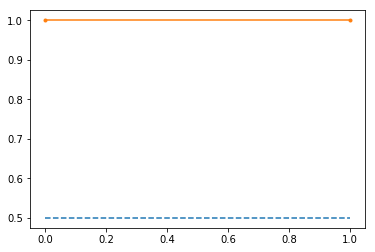

```python
from sklearn.metrics import auc
from sklearn.metrics import average_precision_score
from sklearn.metrics import precision_recall_curve

# predict probabilities
probs = dt_best.predict_proba(X_test)

# keep probabilities for the positive outcome only
probs = probs[:, 1]

# predict class values
y_prd_class_val = dt_best.predict(X_test)

# calculate precision-recall curve
precision, recall, thresholds = precision_recall_curve(y_test, probs)

# calculate F1 score
f1 = f1_score(y_test, y_prd_class_val)

# calculate precision-recall AUC
auc = auc(recall, precision)
# calculate average precision score
ap = average_precision_score(y_test, probs)
print('f1=%.3f auc=%.3f ap=%.3f' % (f1, auc, ap))
# plot no skill
pyplot.plot([0, 1], [0.5, 0.5], linestyle='--')
# plot the precision-recall curve for the model
pyplot.plot(recall, precision, marker='.')
# show the plot
pyplot.show()
```

#### 3. PCA - Linear SVC - No miss classification, TP= 76, TN=81

#### 4. PCA - SVC kernel RBF - No miss classification Tp = 76, TN = 81

#### 5. PCA - SVC- POlY- No miss classification Tp = 76, TN = 81

#### 6. Decision Tree - Best PArams with max_depth=4, No miss classification: Tp = 76, TN = 81